# NISRA Technology and Support Lab RAP Skeleton Demo Report

## 2. Introduction

This section gives some simple information about the report. The information comes from [NISRA’s 2022 Population Estimates for Northern Ireland](https://www.nisra.gov.uk/publications/2022-mid-year-population-estimates-northern-ireland). The data shows how many people live in Northern Ireland, their ages, and whether they are male or female. The information covers the years from 2001 to 2022.

You can also format source information like this:

> Source: [NISRA 2022 Mid Year Population Estimates for Northern Ireland](https://www.nisra.gov.uk/publications/2022-mid-year-population-estimates-northern-ireland)

Sources can be shown below charts and tables. Add the source using the `fig.cap` option in an R Markdown code block. The source will then appear underneath the figure.

### Publication structure

#### Good practice

Recommended structure

1. Key points.
2. Main analysis in numbered sections.
3. Methodology and supporting information (or consider extracting repetitive background content into separate outputs).
4. Contact details.

#### Accessibility

Key accessibility features built-in

- The language element is set to English, in the YAML section of the code.
- There is a named accessibility contact at the end of the document.
- The code contains landmark regions to make it easier for screen reader users to navigate.
- Headings, lists, tables and so on are marked up for assistive technologies.

Headings help organise a report and make it easier to read and scan. They are also important for people who use screen readers. Screen readers help people who have difficulty seeing by reading the text out loud.

HTML headings

- Use the main title only once (h1).
- Use heading 2 (h2) for all section titles.
- Do not use **bold** or *italic* text instead of a heading.
- Do not make headings by only changing the colour or size of the text.
- Use headings in order, and do not skip heading levels (e.g. h1, h2, h3, h4).

You can find more help about writing accessible reports in the Drupal user manual and other accessibility guidance on MS Teams.

## 3. Infographics and images

### Type the title of infographic here

Example infographic with 4 key statistics presented in a logical order from left to right.

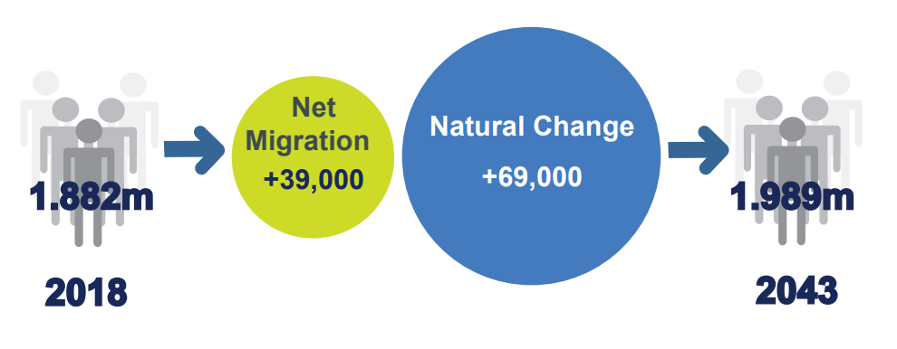

```r
# file is in image folder
knitr::include_graphics("../demo/demo_data/images/PopInfographic.png")
```

Source: 2019 Mid-year population estimates

#### Accessible infographics

- Explain the key message from the infographic in the report text.
- Add alt text so that screen reader users can understand the image.
- If an image is only for decoration, use empty alt text.
- Do not put important text information in images, make sure it appears as text in the report.
- Use accessible colours and make sure text has good contrast against the background.

For more help, see the Dissemination Branch guide [Creating an accessible infographic](https://nicsonline.sharepoint.com/:u:/s/TM-DOF-NISRATEAM/IQAVFYCBi8ZWR64U9kMdk2DcAUfVs_bFTnc1OrObMxVnyrA?e=dU9Uyb). You can also use the [Government Analysis Function guide to infographics](https://gss.civilservice.gov.uk/policy-store/infographics/).

**Important**: If you use SVG images with text, check if screen readers can read the text. You can test this using Microsoft Narrator. If it does announce the words in the image, ensure it makes sense to users. If not, you can use a PNG and add alt text.

## 4. Tables

### Good practice

The Government Analysis function makes a distinction between demonstration tables and reference tables. Demonstration tables are used to reinforce a point made in the text of a publication. They are smaller and less detailed than reference tables.

#### Accessible tables

Keep the structure of tables simple so everyone can use them. This is especially important for people who use screen readers.

To ensure tables are clear and easy to read:

- do not merge cells
- do not leave rows or columns blank
- give every column a heading
- make sure all headings and labels are easy to see
- round numbers in the same way throughout the table
- align text to the left and numbers to the right
- use commas in large numbers, for example 1,000
- avoid abbreviations or explain them the first time you use them
- add labels such as %, £, or millions to the heading instead of repeating them in each cell
- do not use symbols such as * or superscripts for notes or explanations
- use [note] with numbers for notes

### Basic table

#### Table 1: Mid Ulster had the highest proportion of under 25s

**Select the tab to view population of young or elderly people.**

##### 1a Population of young people by LGD

```r
# kable code needs to be created as a string to allow correct rendering of
# source code on second tab

kable(df_mye_latest_year_youthrate,

  # left align text, right align numbers
  align = ("lrrr"),

  # full and descriptive headings
  col.names = c(
    "Local Government District (LGD)",
    "Young people in LGD",
    "Total population of LGD",
    "Young people as percentage"
  ),

  # use caption to keep text associated with table
  caption = paste0(
    "Population of young people by Local Government District in NI, ",
    latest_year
  ),

  # add thousand separator
  format.args = list(big.mark = ","),
  label = NA
) |>
  kable_styling()
```

Population of young people by Local Government District in NI, 2022

| Local Government District (LGD) | Young people in LGD | Total population of LGD | Young people as percentage |
| --- | --- | --- | --- |
| Antrim and Newtownabbey | 43,399 | 146,148 | 29.7 |
| Ards and North Down | 43,686 | 164,223 | 26.6 |
| Armagh City, Banbridge and Craigavon | 69,994 | 220,271 | 31.8 |
| Belfast | 113,076 | 348,005 | 32.5 |
| Causeway Coast and Glens | 41,392 | 141,316 | 29.3 |
| Derry City and Strabane | 47,552 | 150,836 | 31.5 |
| Fermanagh and Omagh | 36,180 | 116,994 | 30.9 |
| Lisburn and Castlereagh | 43,265 | 149,915 | 28.9 |
| Mid Ulster | 50,409 | 151,001 | 33.4 |
| Mid and East Antrim | 39,019 | 139,200 | 28.0 |
| Newry, Mourne and Down | 58,475 | 182,634 | 32.0 |

Commentary describing the key messages you want readers to take from the table could go here.

##### 1b Population of elderly people by LGD

```r
# kable code needs to be created as a string to allow correct rendering of
# source code on fourth tab

kable(df_mye_latest_year_elderlyrate,

  # left align text, right align numbers
  align = ("lrrr"),

  # full and descriptive headings
  col.names = c(
    "Local Government District (LGD)",
    "Elderly people in LGD",
    "Total population of LGD",
    "Elderly people as percentage"
  ),

  # use caption to keep text associated with table
  caption = paste0(
    "Population of elderly people by Local Government District in NI, ",
    latest_year
  ),

  # add thousand separator
  format.args = list(big.mark = ","),
  label = NA
) |>
  kable_styling()
```

Population of elderly people by Local Government District in NI, 2022

[output not shown]

The key messages you want the readers to take from the table could go here.

### Pagination

#### Table 2: Northern Ireland population is growing year on year (h4)

```r
datatable(df_mye_year_gender_t,
  # DT creates row numbers by default. Suppress to ensure all cols have a header
  rownames = FALSE,
  # Rename column headers to make them descriptive
  colnames = c(
    "Mid Year Ending",
    "Females",
    "Males",
    "NI Population Total"
  ),
  caption = paste0(
    "Number of males and females making up the total NI population from ",
    earliest_year,
    "-",
    latest_year
  ),
  # left align first column and add thousand separator to numbers
  options = list(
    columnDefs = list(
      list(
        className = "dt-left",
        targets = 0
      )
    )
  )
) |>
  formatRound(
    c(
      "Females",
      "Males",
      "All persons"
    ),
    digits = 0,
    interval = 3,
    mark = ","
  )
```

| Mid Year Ending | Females | Males | NI Population Total |
| --- | --- | --- | --- |
| 2001 | 864565 | 824273 | 1688838 |
| 2002 | 868548 | 828986 | 1697534 |
| 2003 | 871820 | 833104 | 1704924 |
| 2004 | 875791 | 838251 | 1714042 |
| 2005 | 882432 | 845301 | 1727733 |
| 2006 | 890003 | 853110 | 1743113 |
| 2007 | 899427 | 862256 | 1761683 |
| 2008 | 908154 | 870998 | 1779152 |
| 2009 | 914771 | 878562 | 1793333 |
| 2010 | 920298 | 884535 | 1804833 |

[output cut: 12 more lines]

This is descriptive commentary to highlight the key points in the table above. There are more females than males year on year. Population growth is driven by both sexes.

### Cross-tabulation

#### Table 3: Under 25s were the largest age group in Northern Ireland

```r
cross_tab_data <- df_mye_latest_year_agegrp_gend |>
  pivot_wider(
    names_from = gender,
    values_from = pop_total
  ) |>
  mutate(
    persons = Males + Females
  )

cross_tab_data["Female_Male_ratio_100"] <-
  round_half_up(
    cross_tab_data$Females / cross_tab_data$Males * 100, 0
  )

# Adding thousand separator
cross_tab_data$Females <- prettyNum(
  cross_tab_data$Females,
  big.mark = ","
)
cross_tab_data$Males <- prettyNum(
  cross_tab_data$Males,
  big.mark = ","
)
cross_tab_data$persons <- prettyNum(
  cross_tab_data$persons,
  big.mark = ","
)

kable(
  cross_tab_data,
  # left row labels, right align numbers
  align = "lrrrr",
  # make column headings clear and descriptive
  col.names = c(
    "Age group",
    "Females",
    "Males",
    "Total persons",
    "Number of females to every 100 males"
  ),
  # use caption for descriptive title
  caption = paste0(
    "Northern Ireland population by broad age band and sex ",
    latest_year
  ),
) |>
  kable_styling()
```

Northern Ireland population by broad age band and sex 2022

| Age group | Females | Males | Total persons | Number of females to every 100 males |
| --- | --- | --- | --- | --- |
| 0-24 | 285,014 | 301,433 | 586,447 | 95 |
| 25-44 | 252,835 | 241,141 | 493,976 | 105 |
| 45-64 | 252,234 | 242,437 | 494,671 | 104 |
| 65 plus | 180,513 | 154,936 | 335,449 | 117 |

### Table with colour scales

#### Table 4: Belfast saw the greatest increase in population from 2021 to 2022

```r
# function to add thousand separator
mycomma <- function(digits = 0) {
  require(formattable)
  formatter(
    "span",
    x ~ comma(
      x,
      digits = digits
    )
  )
}

# up and down arrows added to column four
# colour tiles added to column five. Colour selected is a lighter shade of
# nisra_blue (which failed accessibility check). Seems that colour specified in
# code is the mid point of the tiles generated so needs to be pale to ensure
# contrast for higher levels is sufficient.
t4 <- formattable(
  df_t4_html,
  align = c("lrrrr"),
  list(
    area(col = 2:3) ~ mycomma(digits = 0), # apply mycomma fn
    area(col = 5) ~ color_tile("transparent", "#7ca6da"),
    `Change` = formatter(
      "span",
      style = ~ style(
        color = ifelse(
          `Change` > 0,
          "black",
          "#e60000"
        )
      ),
      ~ icontext(
        ifelse(
          `Change` > 0,
          "arrow-up",
          "arrow-down"
        ),
        format(
          `Change`,
          big.mark = ","
        )
      )
    )
  )
)

t4
```

| LGD | 2022 population | 2021 population | Change | Change (%) |
| --- | --- | --- | --- | --- |
| Antrim and Newtownabbey | 146,148 | 145,852 | 296 | 0.2 |
| Ards and North Down | 164,223 | 163,827 | 396 | 0.2 |
| Armagh City, Banbridge and Craigavon | 220,271 | 219,127 | 1,144 | 0.5 |
| Belfast | 348,005 | 344,992 | 3,013 | 0.9 |
| Causeway Coast and Glens | 141,316 | 141,664 | -348 | -0.2 |
| Derry City and Strabane | 150,836 | 150,834 | 2 | 0.0 |
| Fermanagh and Omagh | 116,994 | 116,926 | 68 | 0.1 |
| Lisburn and Castlereagh | 149,915 | 149,272 | 643 | 0.4 |
| Mid Ulster | 151,001 | 150,598 | 403 | 0.3 |
| Mid and East Antrim | 139,200 | 139,127 | 73 | 0.1 |
| Newry, Mourne and Down | 182,634 | 182,345 | 289 | 0.2 |

Ensure sufficient contrast between background colours and the text when using colour scales.

## 5. Charts

This section includes different types of charts. These include line charts, column charts, pie charts, tree maps and a donut chart.

### Good practice for charts

- Give charts a primary title describing the main trend or message (see examples below).
- Add a statistical subtitle that explains the measure, location and time period.
- Clearly label data and categories.
- Show all chart text horizontally, including axis labels.
- Write labels in full instead of using abbreviations.
- If you need to use abbreviations, explain them the first time you use them.
- Avoid using a legend where possible.
- If you need a legend, place it above the chart.
- Avoid using charts with two axes.

### Accessible charts

#### Colours

- Do not use colour on its own to show information (e.g. to read a legend).
- Make sure chart colours are easy to tell apart and easy to see against the background.
- There is an accessible colour palette on the Dissemination channel on NISRA Teams
- Check contrast at least 3:1 for chart elements.
- Check contrast is at least 4.5:1 for text.

#### Help users access chart data and key messages

- Explain the main message(s) of the chart in text above or below it (i.e. provide a clear text alternative).
- Provide the chart data in CSV or Excel format, or give users a way to request it.
- Add alt text to static chart images describing the chart type and content.
- Think about how a screen reader will read labels and punctuation if your charts are interactive.
- Make sure charts work well on different screen sizes, such as mobile phones, laptops and desktop computers.
- Be aware of how interactive (e.g. Plotly) charts resize:
  - annotations easily get crowded and overlap.
  - plotly resizes the x axis which alters how the trend is perceived.
- Consider adding a message for mobile users to turn their phone sideways to view the chart.
- If you create charts with the Plotly package, turn off the Plotly logo and icons. This helps reduce auditory clutter and avoids unnecessary repeated links.

For more information, see the [UK Government Analysis Function (GAF) guidance on designing charts](https://analysisfunction.civilservice.gov.uk/policy-store/data-visualisation-charts/).

### Single line chart

This section shows a static line chart and an interactive line chart.

#### Chart features

- Text (including labels) and lines all have good colour contrasts against white background.
- Data labels are at the end of the line to prevent overlap when the chart changes size on different devices.

Add clear descriptive text before or after the chart. This helps all users understand the main message of the chart.

#### Non-zero axes

To add a broken axis symbol to a plotly chart, use the “fn_break_axis” function. Set the linecolor to match the colour used for the “y-axis” in the layout settings. This function is a NISRA created function that can be found in the functions folder. It can only be used with plotly charts.

To add a broken axis symbol to a ‘ggplot’ chart, add it as an annotation. The ‘ggplot’ package does not provide a built-in broken feature.

The code below shows how to add a broken axis symbol to both ‘plotly’ and ‘ggplot’ charts.

#### Figure 1: Mid year population estimates continue to increase

##### Northern Ireland mid year population estimate (total) between 2001 and 2022

###### Figure 1 plotly

```r
year1_lab <- list(
  x = ~ mid_year_ending[1] + 0.5,
  y = ~ ni_pop_total[1], # sets position of label
  xanchor = "right",
  yanchor = "middle", # alignment of label
  text = ~ paste0(
    earliest_year,
    ": \n",
    round_half_up(
      ni_pop_total[1] / 1e6,
      2
    ),
    "m"
  ),
  # punctuated and formatted label text
  showarrow = FALSE, # turn off otherwise get line between label and chart
  font = list(
    size = 14,
    color = nisra_blue
  )
)

year2_lab <- list(
  x = ~ tail(
    mid_year_ending,
    n = 1
  ), # position at last value of x variable
  y = ~ tail(
    ni_pop_total,
    n = 1
  ), # position at last value of y variable
  xanchor = "left",
  yanchor = "middle", # alignment
  # punctuated and formatted label text
  text = ~ paste0(
    latest_year,
    ": \n",
    round_half_up(
      tail(
        ni_pop_total, 1
      ) / 1e6,
      2
    ),
    "m"
  ),
  showarrow = FALSE,
  font = list(
    size = 14,
    color = nisra_blue
  )
)
# create annotations
# annotation on vertical line
note_1 <- list(
  x = 0.41,
  y = 1,
  text = "2009",
  showarrow = FALSE,
  xref = "paper",
  yref = "paper",
  xanchor = "left",
  align = "left",
  font = list(
    size = 14,
    color = nisra_navy,
    family = "Arial black"
  )
)
# use annotation rather than y axis title variable for horizontal text
yaxistitle <- list(
  x = 0.02,
  y = 1.03,
  text = "Population (Millions)",
  showarrow = FALSE,
  xref = "paper",
  yref = "paper",
  xanchor = "center",
  yanchor = "middle",
  xshift = 0,
  yshift = 0,
  font = list(
    size = 14,
    color = "black"
  )
)
# Create the caption - Note the non-zero axis
note_2 <- list(
  x = 0.75,
  y = -0.115,
  text = "Note the non-zero axis",
  showarrow = FALSE,
  xref = "paper",
  yref = "paper",
  xanchor = "left",
  align = "left",
  font = list(
    size = 14,
    color = nisra_navy
  )
)
# aesthetic definitions for vertical line used in fig1
vline <- function(x = 0, color = nisra_navy) {
  list(
    type = "line",
    y0 = 0,
    y1 = 1,
    yref = "paper",
    x0 = x,
    x1 = x,
    line = list(
      color = color,
      dash = "dot"
    )
  )
}

# create line chart (type = scatter and mode = line)
fig1 <- plot_ly(
  df_annual_pop_tot,
  x = ~mid_year_ending,
  y = ~ni_pop_total,
  name = "Northern Ireland population",
  line = list(
    color = nisra_blue
  ),
  type = "scatter",
  mode = "line",
  hoverinfo = "text",
  text = ~ paste0(
    mid_year_ending,
    ": ",
    format(
      round_half_up(
        ni_pop_total / 1e6,
        2
      ),
      nsmall = 2
    ),
    "m"
  )
) |>
  layout(
    showlegend = FALSE,
    font = list(
      family = "Arial",
      size = 14
    ),
    xaxis = list(
      title = "Year",
      showline = TRUE,
      linecolor = "#000000",
      showgrid = FALSE,
      showticklabels = TRUE,
      range = c(
        1999,
        2024
      ),
      ticks = "outside",
      tickwidth = 2
    ),
    yaxis = list(
      title = "",
      showline = TRUE,
      linecolor = "#000000",
      showgrid = FALSE
    ),
    annotations = list(
      year1_lab,
      year2_lab,
      note_1,
      yaxistitle,
      note_2
    )
  ) |>
  # To add the broken axis symbol pipe the function "fn_break_axis" with
  # "linecolor" matching the colour given above. This function is a NISRA
  # created function that can be found in the functions folder.
  fn_break_axis(
    linecolor = "#000000",
    ref_line = vline(2009)
  ) |>
  f_responsive_annotations()
# modebar is series of icons and plotly logo linked to plotly site. Turned off
# throughout to avoid multiple links going to same destination (poor
# accessibility) and icons can create visual clutter.
fig1 <- fig1 |>
  config(
    displayModeBar = FALSE
  )

fig1 <- htmlwidgets::onRender(
  fig1,
  "
  function(el, x) {
    window.fig1_chart = el;

    setTimeout(function() {
      Plotly.Plots.resize(el);
    }, 200);
  }
  "
)

fig1
```

[interactive chart not shown]

**Download**

Figure 1.CSV (1kB)

Figure 1.XLSX (7kB)

Figure 1 as image

###### Figure 1 plotly zero axis

```r
year1_lab <- list(
  x = ~ mid_year_ending[1],
  y = ~ ni_pop_total[1], # sets position of label
  xanchor = "right",
  yanchor = "middle", # alignment of label
  text = ~ paste0(
    earliest_year,
    ": \n",
    round_half_up(
      ni_pop_total[1] / 1e6,
      2
    ),
    "m"
  ),
  # punctuated and formatted label text
  showarrow = FALSE, # turn off otherwise get line between label and chart
  font = list(
    size = 14,
    color = nisra_blue
  )
)

year2_lab <- list(
  x = ~ tail(
    mid_year_ending,
    n = 1
  ), # position at last value of x variable
  y = ~ tail(
    ni_pop_total,
    n = 1
  ), # position at last value of y variable
  xanchor = "left",
  yanchor = "middle", # alignment
  # punctuated and formatted label text
  text = ~ paste0(
    latest_year,
    ": \n",
    round_half_up(
      tail(ni_pop_total, 1) / 1e6,
      2
    ),
    "m"
  ),
  showarrow = FALSE,
  font = list(
    size = 14,
    color = nisra_blue
  )
)

# create annotations
# annotation on vertical line
note_1 <- list(
  x = 0.41,
  y = 1, # position of annotation
  text = "2009",
  showarrow = FALSE,
  xref = "paper",
  yref = "paper",
  xanchor = "left",
  align = "left",
  font = list(
    size = 14,
    color = nisra_navy,
    family = "Arial black"
  )
)

# use annotation rather than y axis title variable for horizontal text
yaxistitle <- list(
  x = 0.02,
  y = 1.06,
  text = "Population (Millions)",
  showarrow = FALSE,
  xref = "paper",
  yref = "paper",
  xanchor = "center",
  yanchor = "centre",
  xshift = 0,
  yshift = 0,
  font = list(
    size = 14,
    color = "black"
  )
)

# aesthetic definitions for vertical line used in fig1
vline <- function(x = 0, color = nisra_navy) {
  list(
    type = "line",
    y0 = 0,
    y1 = 1,
    yref = "paper",
    x0 = x,
    x1 = x,
    line = list(
      color = color,
      dash = "dot"
    )
  )
}

# create line chart (type = scatter and mode = line)
fig1 <- plot_ly(
  df_annual_pop_tot,
  x = ~mid_year_ending,
  y = ~ni_pop_total,
  name = "Northern Ireland population",
  line = list(
    color = nisra_blue
  ),
  type = "scatter",
  mode = "line",
  hoverinfo = "text",
  # formatting hover text to millions(m) to 2dp
  text = ~ paste0(
    mid_year_ending,
    ": ",
    format(
      round_half_up(
        ni_pop_total / 1e6,
        2
      ),
      nsmall = 2
    ),
    "m"
  )
) |>
  layout(
    showlegend = FALSE,
    font = list(
      family = "Arial",
      size = 14
    ),
    xaxis = list(
      title = "Year",
      showline = TRUE,
      linecolor = "#000000",
      showgrid = FALSE,
      showticklabels = TRUE,
      range = c(
        1999,
        2024
      ),
      ticks = "outside",
      tickwidth = 2
    ),
    yaxis = list(
      title = "",
      showline = TRUE,
      range = c(
        0,
        2100000
      ),
      linecolor = "#000000",
      showgrid = FALSE
    ),
    annotations = list(
      year1_lab,
      year2_lab,
      note_1,
      yaxistitle
    )
  ) |>
  layout(
    shapes = list(
      vline(2009)
    )
  ) |>
  f_responsive_annotations()

# modebar is series of icons and plotly logo linked to plotly site. Turned off
# throughout to avoid multiple links going to same destination (poor
# accessibility) and icons can create visual clutter.
fig1 <- fig1 |>
  config(
    displayModeBar = FALSE
  )

fig1 <- htmlwidgets::onRender(
  fig1,
  "
  function(el, x) {
    window.fig1_zero_chart = el;
  }
  "
)

fig1
```

[interactive chart not shown]

**Download**

Figure 1.CSV (1kB)

Figure 1.XLSX (7kB)

Figure 1 as image

###### Figure 1 static

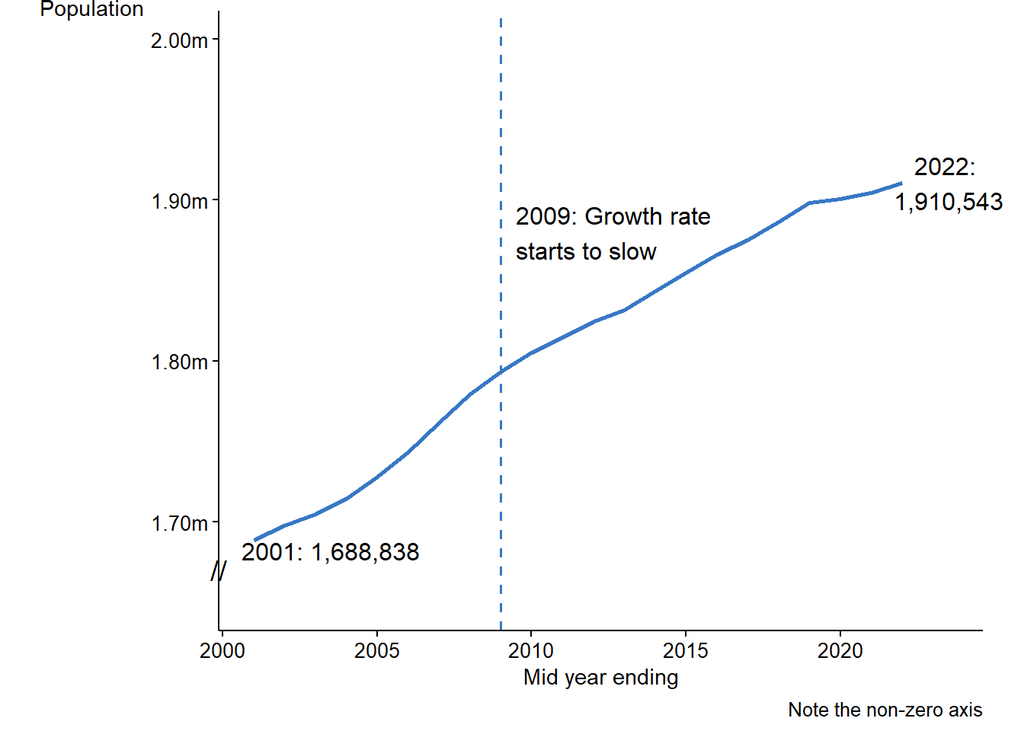

```r
fig1_static <- ggline(
  df_annual_pop_tot,
  x = "mid_year_ending",
  y = "ni_pop_total",
  plot_type = "l",
  color = nisra_blue,
  linetype = "solid",
  size = 1,
  caption = "Note the non-zero axis",
  xlim = c(
    2000,
    2026
  ),
  xlab = "Mid year ending",
  ylab = "Population"
) +
  font(
    "ylab",
    angle = 0,
    vjust = 1.02
  ) +
  scale_y_continuous(
    limits = c(
      1650000,
      2000000
    ),
    labels = scales::label_number(
      suffix = "m",
      scale = 1e-6,
      big.mark = ","
    )
  ) +
  theme(
    text = element_text(
      family = "Arial"
    )
  ) +
  theme(
    axis.title = element_text(
      size = 11
    ),
    axis.text = element_text(
      size = 10
    ),
    # give a bit of room at the left for the slashes if needed
    plot.margin = margin(
      5.5,
      20,
      5.5,
      20
    )
  ) +
  geom_text(
    data = df_annual_pop_tot |>
      filter(
        mid_year_ending == latest_year
      ),
    aes(
      label = paste0(
        latest_year,
        ": \n",
        format(
          ni_pop_total,
          big.mark = ","
        )
      ),
      x = mid_year_ending + 1.5,
      y = ni_pop_total
    )
  ) +
  geom_text(
    data = df_annual_pop_tot |>
      filter(
        mid_year_ending == earliest_year
      ),
    aes(
      label = paste0(
        earliest_year,
        ": ",
        format(
          ni_pop_total,
          big.mark = ","
        )
      ),
      x = mid_year_ending + 2.5,
      y = ni_pop_total - 7000
    )
  ) +
  geom_vline(
    xintercept = 2009,
    linetype = "dashed",
    color = nisra_blue
  ) +
  annotate(
    "text",
    x = 2009.5,
    y = 1880000,
    hjust = 0,
    label = paste(
      strwrap(
        "2009: Growth rate starts to slow",
        width = 18
      ),
      collapse = "\n"
    )
  ) +
  # --- Add a “fake” axis-break mark (two slashes) near the left axis ---
  coord_cartesian(
    clip = "off"
  ) +
  annotate(
    "text",
    x = min(
      df_annual_pop_tot$mid_year_ending
    ),
    y = 1.67e6,
    label = "//",
    hjust = 2.55, # nudges further left
    vjust = 0.5,
    size = 5
  )

fig1_static
```

**Download**

Figure 1.CSV (1kB)

Figure 1.XLSX (7kB)

Figure 1 as image

Further information on the chart download buttons can be found in section 7. Download data of the demo report.

### Multiple lines chart

This section shows a line chart with more than one line. The lines are easy to see because they do not overlap.

#### Features

- The chart uses good contrast (different shades of the same colour) to distinguish between males and females.
- The legend is placed above the chart.
- A static chart is used here so it views well on mobile as well as desktop.

Include descriptive text before or after the chart.

#### Figure 2: Females outnumber males in total population

##### Northern Ireland mid year population estimate (sex) 2001 to 2022

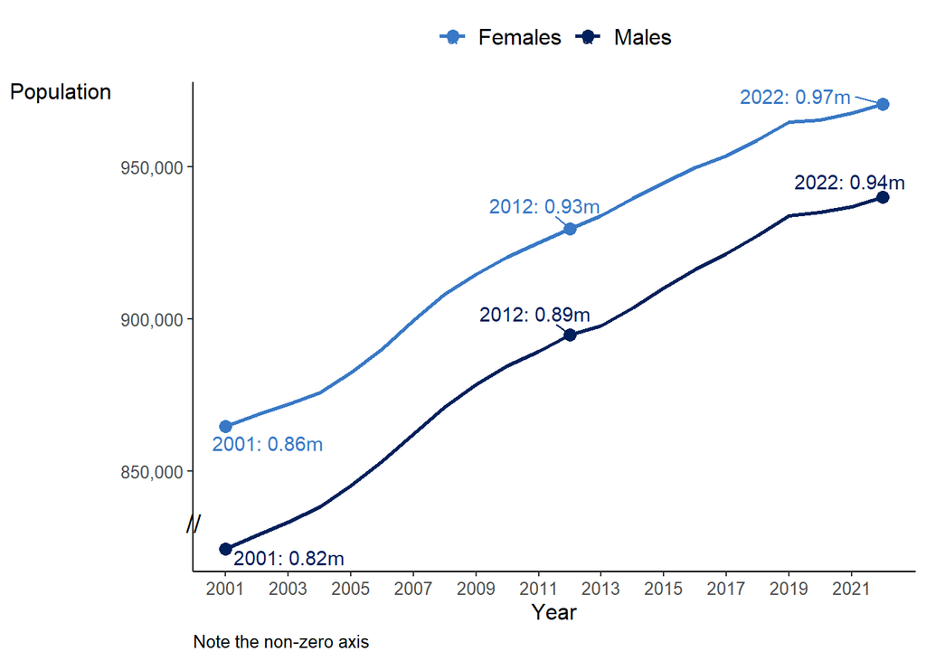

```r
# Create separate dataframe for selected datapoints from main dataframe
df_mye_selected_years_gender <- df_mye_year_gender |>
  filter(
    mid_year_ending %in% c(
      2001,
      2012,
      2022
    )
  ) |>
  # format numbers
  mutate(
    label = paste0(
      mid_year_ending,
      ": ",
      round_half_up(
        mye_pop / 1e6,
        2
      ),
      "m"
    )
  )


# code to create interpolated points with blank labels along the line of the
# line plot to cause repulsion of labels from line and avoid overlap - the
# final df, df_fig2_labs_inter is used in the geom_text_repel statement

df_mye_interp_male <- filter(
  df_mye_year_gender,
  gender == "Males"
)

df_mye_interp_male <- as.data.frame(
  do.call(
    cbind,
    approx(
      df_mye_interp_male$mid_year_ending,
      df_mye_interp_male$mye_pop,
      n = 30
    )
  )
)

df_mye_interp_female <- filter(
  df_mye_year_gender,
  gender == "Females"
)

df_mye_interp_female <- as.data.frame(
  do.call(
    cbind,
    approx(
      df_mye_interp_female$mid_year_ending,
      df_mye_interp_female$mye_pop,
      n = 30
    )
  )
)

df_mye_interp_male$label <- ""
df_mye_interp_male$Gender <- "Males"

df_mye_interp_male <- df_mye_interp_male |>
  select(
    x,
    Gender,
    y,
    label
  )

colnames(df_mye_interp_male) <- colnames(
  df_mye_selected_years_gender
)

df_mye_lab_select_male <- filter(
  df_mye_selected_years_gender,
  gender == "Males"
)

df_mye_interp_male <- rbind(
  df_mye_lab_select_male,
  df_mye_interp_male
)

df_mye_interp_female$label <- ""
df_mye_interp_female$Gender <- "Females"

df_mye_interp_female <- df_mye_interp_female |>
  select(
    x,
    Gender,
    y,
    label
  )

colnames(df_mye_interp_female) <- colnames(
  df_mye_selected_years_gender
)

df_mye_lab_select_female <- filter(
  df_mye_selected_years_gender,
  gender == "Females"
)

df_mye_interp_female <- rbind(
  df_mye_lab_select_female,
  df_mye_interp_female
)

df_fig2_labs_inter <- rbind(
  df_mye_interp_male,
  df_mye_interp_female
)

df_fig2_labs_inter <- arrange(
  df_fig2_labs_inter,
  mid_year_ending,
  gender
)


fig2 <- ggplot(
  df_mye_year_gender,
  aes(
    x = mid_year_ending,
    y = mye_pop,
    color = gender
  )
) +
  geom_line(
    linewidth = 1
  ) +
  # ACC: Change to line colours with sufficient contrast
  scale_color_manual(
    values = c(
      nisra_blue,
      nisra_navy
    )
  ) +

  # Using NITotals_lab_select_multiple from above to pick the years that will
  # have "points", specifying the size of the dots
  geom_point(
    data = df_mye_selected_years_gender,
    aes(
      x = mid_year_ending,
      y = mye_pop
    ),
    size = 3
  ) +
  labs(
    x = "Year",
    y = "Population",
    caption = "Note the non-zero axis"
  ) +
  theme_bw() +
  theme(
    # removes grid lines from chart
    panel.grid = element_blank(),
    # removes chart border top and right
    panel.border = element_blank(),
    axis.line.x = element_line(
      colour = "#000000"
    ),
    axis.line.y = element_line(
      colour = "#000000"
    ),
    # ACC: make y axis title horizontal and position it further from y axis line
    axis.title.y = element_text(
      angle = 0,
      vjust = 1,
      hjust = 0,
      margin = margin(
        t = 0,
        r = 5,
        b = 0,
        l = 0
      )
    ),
    # align title and subtitle to left
    plot.title.position = "plot",
    # align caption to left
    plot.caption = element_text(
      hjust = 0
    ),
    # ACC: change all fonts to 12
    text = element_text(
      size = 12,
      family = "Arial"
    ),
    # bolds title and subtitle + adds margin below subtitle and plot
    plot.title = element_text(
      face = "bold"
    ),
    plot.subtitle = element_text(
      face = "bold",
      margin = margin(
        0,
        0,
        15,
        0
      )
    ),
    # ACC: Legend to top and tidy up
    legend.position = "top",
    legend.title = element_blank(),
    legend.text = element_text(
      size = 12
    )
  ) +
  geom_text_repel(
    # ACC: show value label for specified years
    data = df_fig2_labs_inter,
    aes(
      x = mid_year_ending,
      y = mye_pop,
      label = label
    ),
    force = 10
  ) +
  # ACC: make x axis labels easier to read by removing every other year
  scale_x_continuous(
    breaks = seq(
      earliest_year,
      latest_year,
      by = 2
    )
  ) +
  # add comma to y labels
  scale_y_continuous(
    labels = label_number(
      scale = 1e0,
      big.mark = ","
    )
  ) +
  # indicate non zero axis
  labs(
    tag = "//"
  ) +
  theme(
    plot.tag.position = c(
      0.203,
      0.2
    )
  )

fig2
```

**Download**

Figure 2.CSV (1kB)

Figure 2.XLSX (8kB)

Figure 2 as image

### Multiple single line charts

This section shows a different way to display data that would otherwise have too many lines. The Government Analysis Function recommends aiming for no more than 4 lines.

#### Features

- These ‘small multiples’ (sometimes called ‘panel charts’) are an option for more than 4 lines.
- The y axis is identical on all charts.
- This chart is static because it works well on mobiles and when magnified.

You could also highlight one line in colour and make all the other lines grey if that shows your message more clearly.

Add clear text before or after the chart to explain the main message.

#### Figure 3: In 2022, Belfast Local Government District (LGD) has more younger people than other areas

##### Northern Ireland mid year population estimate by LGD in 2022

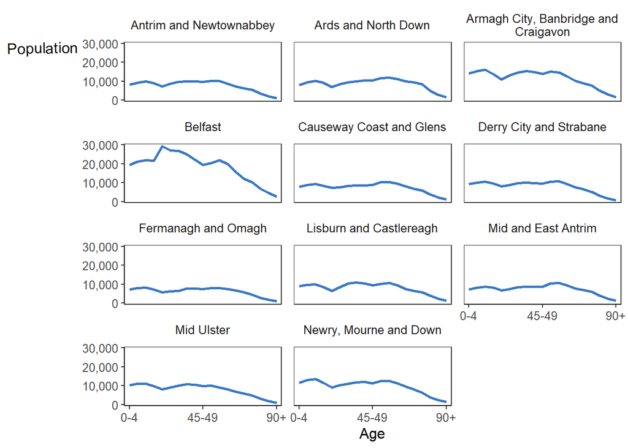

```r
fig3 <- ggplot(
  df_mye_latest_5yr_age_lgd,
  aes(
    x = age_group_5,
    y = population_latest
  )
) +
  geom_line(
    linewidth = 1,
    group = 1,
    color = nisra_blue
  ) +
  # ACC: Specify line colour with sufficient contrast
  facet_wrap(
    vars(
      str_wrap(
        lgd2014name,
        30
      )
    ),
    ncol = 3
  ) +
  # ACC: Use clear and descriptive labels
  labs(
    x = "Age",
    y = "Population"
  ) +
  theme_bw() +
  theme(
    # removes grid lines from chart
    panel.grid = element_blank(),
    # panel margin
    panel.spacing.x = unit(
      0.7,
      "lines"
    ),
    axis.line.x = element_line(
      colour = "#000000"
    ),
    axis.line.y = element_line(
      colour = "#000000"
    ),
    # ACC: make y axis title horizontal and position it further from y axis line
    axis.title.y = element_text(
      angle = 1,
      vjust = 1,
      hjust = 0,
      margin = margin(
        t = 0,
        r = 5,
        b = 0,
        l = 0
      )
    ),
    # ACC: change all fonts to 12
    text = element_text(
      size = 12,
      family = "Arial"
    ),
    # facet only legend hide bg
    legend.title = element_blank(),
    legend.position = "none",
    strip.background = element_blank()
  ) +
  scale_x_discrete(
    breaks = c(
      "0-4",
      "45-49",
      "90-94"
    ),
    labels = c(
      "0-4",
      "45-49",
      "90+"
    )
  ) +
  # ACC: add comma to y labels
  scale_y_continuous(
    labels = label_number(
      scale = 1e0,
      big.mark = ","
    )
  )

fig3
```

**Download**

Figure 3.CSV (3kB)

Figure 3.XLSX (9kB)

Figure 3 as image

### Bar chart (a-z)

#### Features

- Long council names are displayed in full without wrapping or having text at an angle with this orientation of bars.

Include descriptive text before or after the chart.

#### Figure 4: Young people by LGD

##### Data from 2022 mid-year estimates (MYEs) showing the percentage of each LGD population that is under 25

###### Figure 4 static (ggplot)

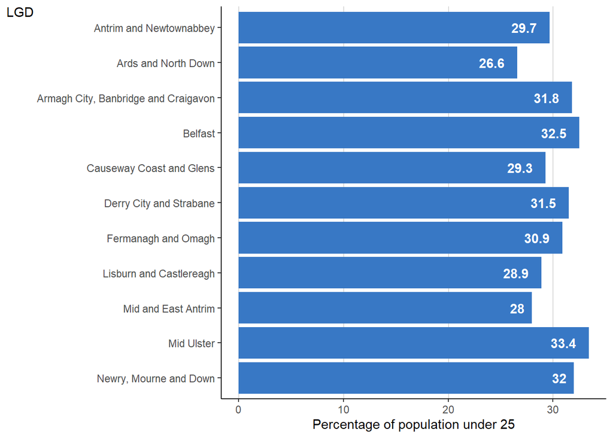

```r
# create amended df for chart. Reorder factors for plotting (need lgd names in
# reverse alphabetical order as coord flip reverses order).
# Remove unnecessary columns
fig4_data <- df_mye_latest_year_youthrate |>
  mutate(
    lgd2014name = fct_reorder(
      lgd2014name,
      desc(lgd2014name)
    )
  ) |>
  select(
    -under25_pop,
    -lgd_pop_total
  )

ggplot(
  fig4_data,
  aes(
    x = lgd2014name,
    y = youthrate
  )
) +
  geom_bar(
    fill = nisra_blue,
    stat = "identity"
  ) +
  geom_text(
    aes(
      label = youthrate
    ),
    hjust = 1.5,
    colour = "white",
    fontface = "bold"
  ) +
  # adds value labels to the bars, sets text to colour and weight that meet
  # contrast standards.
  theme_bw() +
  # axis labels
  labs(
    x = paste(
      strwrap(
        "LGD",
        width = 0.2 * getOption("width")
      ),
      collapse = "\n"
    ),
    y = "Percentage of population under 25"
  ) +
  # makes y axis title horizontal
  theme(
    axis.title.y = element_text(
      angle = 0,
      vjust = 1,
      hjust = 1
    ),
    # removes grids from chart
    panel.grid = element_blank(),
    # added vertical grid at major ticks
    panel.grid.major.x = element_line(
      color = "#BEBEBE",
      linewidth = 0.1
    ),
    # removes chart border top and right
    panel.border = element_blank(),
    # xaxis line black
    axis.line.x = element_line(
      colour = "#000000"
    ),
    # yaxis line black
    axis.line.y = element_line(
      colour = "#000000"
    )
  ) +
  coord_flip()
```

###### Figure 4 interactive (ggplotly)

```r
# Create amended data frame for chart.
# Reorder factors for plotting, as coord_flip() reverses the order.
# Remove unnecessary columns.
fig4_data <- df_mye_latest_year_youthrate |>
  mutate(
    lgd2014name = fct_reorder(
      lgd2014name,
      desc(lgd2014name)
    )
  ) |>
  select(
    -under25_pop,
    -lgd_pop_total
  )

# Create static ggplot
fig4 <- ggplot(
  fig4_data,
  aes(
    x = lgd2014name,
    y = youthrate,
    text = paste0(
      "<b>",
      lgd2014name,
      "</b>",
      "<br>Percentage of population under 25: ",
      sprintf(
        "%.1f",
        youthrate
      )
    )
  )
) +
  geom_bar(
    fill = nisra_blue,
    stat = "identity"
  ) +
  # Set labels for bars
  geom_text(
    aes(
      label = sprintf(
        "%.1f",
        youthrate
      )
    ),
    hjust = 0.9,
    colour = "white",
    fontface = "bold"
  ) +
  theme_bw() +
  labs(
    x = paste(
      strwrap(
        "LGD",
        width = 0.2 * getOption("width")
      ),
      collapse = "\n"
    ),
    y = "Percentage of population under 25"
  ) +
  theme(
    axis.title.y = element_text(
      angle = 0,
      vjust = 1,
      hjust = 0
    ),
    panel.grid = element_blank(),
    panel.grid.major.x = element_line(
      colour = "#BEBEBE",
      linewidth = 0.1
    ),
    panel.border = element_blank(),
    axis.line.x = element_line(
      colour = "#000000"
    ),
    axis.line.y = element_line(
      colour = "#000000"
    )
  ) +
  coord_flip()

# Convert to interactive plotly chart
fig4_interactive <- ggplotly(
  fig4,
  tooltip = "text"
) |>
  layout(
    yaxis = list(
      title = ""
    ),
    # Creates an annotation for the 'LGD' y axis label
    annotations = list(
      list(
        x = -0.1,
        y = 1.01,
        xref = "paper",
        yref = "paper",
        text = "<b>LGD</b>",
        showarrow = FALSE,
        xanchor = "right",
        yanchor = "bottom",
        font = list(
          size = 12
        )
      )
    ),
    margin = list(
      l = 180,
      r = 30,
      t = 40,
      b = 40
    ),
    hoverlabel = list(
      align = "left"
    )
  ) |>
  config(
    displayModeBar = FALSE
  )

# Move the value labels inside the bars
fig4_interactive$x$data[[2]]$x <-
  fig4_interactive$x$data[[2]]$x - 2

fig4_interactive <- htmlwidgets::onRender(
  fig4_interactive,
  "
  function(el, x) {
    window.fig4_chart = el;
  }
  "
)

fig4_interactive
```

[interactive chart not shown]

**Download**

Figure 4.CSV (1kB)

Figure 4.XLSX (7kB)

Figure 4 as image

The chart shows that the LGD with the greatest percentage of population less than 25 is Mid Ulster. Ards and North Down is the LGD with the smallest percentage.

### Interactive bar chart using plotly

This bar chart is created using the same data but using plotly to create an interactive html chart. When resized for mobile the bars shorten but the labels remain a more readable size. Keep the x axis title short so it won’t get cut off on a smaller display.

Include descriptive text before or after the chart highlighting the key message.

#### Figure 5: Proportion of under 25s was higher in 2001.

##### Percentage of population aged under 25 by LGD, 2001 MYEs

Dashed line represents Northern Ireland mean.

```r
# create annotation for y axis title so it can be horizontal.
yaxistitle <- list(
  x = -0.1,
  y = 1.01, # position of y axis title
  text = "LGD", # title
  showarrow = FALSE,
  xref = "paper",
  yref = "paper",
  xanchor = "center",
  yanchor = "middle", # alignment
  xshift = 0,
  yshift = 0,
  font = list(
    family = "Arial Black",
    size = 14,
    color = "black"
  )
)

fig5 <- plot_ly(
  df_mye_earliest_youthrate,
  x = ~earliest_youthrate,
  y = ~lgd2014name,
  type = "bar",
  orientation = "h", # horizontal bars. Default is vertical
  hoverinfo = "text",
  # adds value labels to the bars and sets hover text
  text = ~earliest_youthrate,
  textposition = "auto",
  # sets colour of bars to navy
  marker = list(
    color = nisra_navy
  )
) |>
  layout(
    # add annotation
    font = list(
      family = "Arial",
      size = 14
    ),
    annotations = list(
      yaxistitle
    ),
    shapes = list(
      vline(
        ~ mean(earliest_youthrate),
        color = nisra_blue
      )
    ),
    xaxis = list(
      title = "Under 25s (%)"
    ),
    yaxis = list(
      title = "",
      ticks = "outside",
      tickcolor = "#ffffff",
      ticklen = 10,
      categoryorder = "category descending"
    )
  ) |>
  f_responsive_annotations()

# displays lgds in alphabetic order
# modebar is series of icons and plotly logo linked to plotly site. Turned off
# throughout to avoid multiple links going to same destination (poor
# accessibility) and icons can create visual clutter.

fig5 <- fig5 |>
  config(
    displayModeBar = FALSE,
    displaylogo = FALSE
  )

fig5 <- htmlwidgets::onRender(
  fig5,
  "
  function(el, x) {
    window.fig5_chart = el;
  }
  "
)

fig5
```

[interactive chart not shown]

**Download**

Figure 5.CSV (1kB)

Figure 5.XLSX (7kB)

Figure 5 as image

The chart shows that LGD with the greatest percentage of population under 25 in 2001 was Derry City and Strabane. Ards and North Down was the LGD with the smallest percentage.

### Column chart

This section includes two versions of a column chart (one static, one interactive) and two stacked bar charts.

#### Features

- The contrasting shades of blue make it easy to differentiate between male and female.
- Data labels have been added.
- The order of the legend is the same as the column order.
- The plotly x axis labels are short and don’t overlap when resized.
- The plotly data labels will change to vertical on mobile which is not ideal but the hover labels will be horizontal and legible.
- The plotly stacked bar age group labels are short and resize well on mobile.
- The horizontal stacked bar resizes well because there are only 2 groups. If there were many more a static chart would likely be more appropriate.

Include descriptive text before or after the chart.

#### Figure 6: Females outnumber males in all age groups except the under 25s

##### Northern Ireland population in 2022 by age group

###### ggplot static

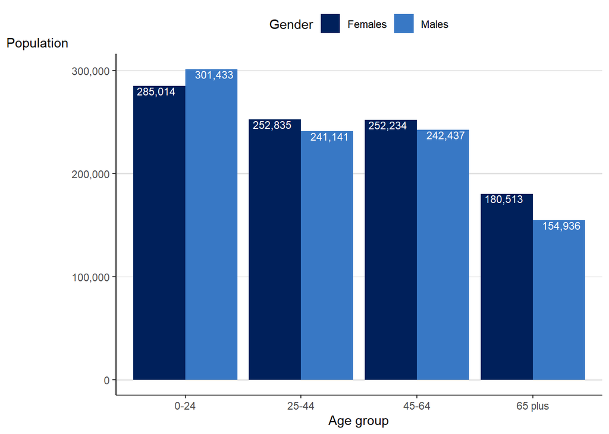

```r
fig6_static <- ggplot(
  df_mye_latest_year_agegrp_gend,
  aes(
    x = age_group,
    y = pop_total,
    fill = gender
  )
) +
  geom_col(
    position = position_dodge()
  ) +
  # colour bars that meet contrast for adjacent colours
  scale_fill_manual(
    values = c(
      nisra_navy,
      nisra_blue
    )
  ) +
  # add value labels, and add thousand separator
  geom_text(
    aes(
      label = prettyNum(
        pop_total,
        big.mark = ","
      )
    ),
    position = position_dodge(
      width = 1
    ),
    vjust = 1.1,
    colour = "white",
    size = 3.2
  ) +
  theme_bw() +
  # axis labels
  labs(
    x = "Age group",
    y = "Population",
    fill = "Gender"
  ) +
  theme(
    axis.title.y = element_text(
      # makes y axis title horizontal
      angle = 0,
      vjust = 1.05,
      hjust = 1
    ),
    # removes grids from chart
    panel.grid = element_blank(),
    # added horizontal grid at major ticks
    panel.grid.major.y = element_line(
      color = "#BEBEBE",
      linewidth = 0.1
    ),
    # removes chart border top and right
    panel.border = element_blank(),
    # xaxis line black
    axis.line.x = element_line(
      colour = "#000000"
    ),
    # yaxis line black
    axis.line.y = element_line(
      colour = "#000000"
    ),
    legend.position = "top"
  ) +
  # add thousand separator to y axis labels
  scale_y_continuous(
    labels = label_number(
      scale = 1e0,
      big.mark = ","
    )
  )

fig6_static
```

**Download**

Figure 6 Static.CSV (1kB)

Figure 6 Static.XLSX (7kB)

Figure 6 Static as image

###### plotly

```r
fig6_grouped <- pivot_wider(
  df_mye_latest_year_agegrp_gend,
  names_from = gender,
  values_from = pop_total
)

fig6_grouped <- as.data.frame(
  fig6_grouped
)

fig6_grouped <- pivot_longer(
  fig6_grouped,
  cols = c(
    Females,
    Males
  ),
  names_to = "variable",
  values_to = "value"
)

nisra_blue <- "#3878c5"
nisra_navy <- "#00205b"

colormap <- setNames(
  object = c(
    "#00205b",
    "#3878c5"
  ),
  nm = unique(
    fig6_grouped$variable
  )
)

fig6_grouped <- fig6_grouped |>
  mutate(
    variable = factor(
      variable,
      levels = c(
        "Females",
        "Males"
      )
    )
  ) |>
  plotly::plot_ly(
    x = ~age_group,
    y = ~value,
    color = ~variable,
    colors = colormap,
    type = "bar",
    text = format(
      fig6_grouped$value,
      big.mark = ","
    ),
    textposition = "inside",
    textangle = "horizontal", # for accessibility
    insidetextfont = list(
      size = 12
    ), # to fit
    hovertemplate = "%{text}", # hover text = text
    textfont = list(
      color = "white"
    )
  ) |>
  layout(
    # makes it a clustered bar
    barmode = "group",
    font = list(
      family = "Arial",
      size = 14
    ),
    xaxis = list(
      title = "Age group"
    ),
    yaxis = list(
      title = "",
      tickformat = ",d",
      showgrid = FALSE
    ),
    legend = list(
      orientation = "h",
      xanchor = "center",
      x = 0.5,
      y = 1.1,
      # so order is same as legend
      traceorder = "normal"
    ),
    annotations = list(
      list(
        text = "Population",
        x = -0.03,
        xref = "paper",
        xanchor = "center",
        y = 1.02,
        yref = "paper",
        yanchor = "bottom",
        showarrow = FALSE,
        font = list(
          size = 16
        )
      )
    )
  ) |>
  # modebar is series of icons and plotly logo linked to plotly site. Turned off
  # throughout to avoid multiple links going to same destination (poor
  # accessibility) and icons can create visual clutter.
  config(
    displayModeBar = FALSE
  )

fig6_grouped <- htmlwidgets::onRender(
  fig6_grouped,
  "
  function(el, x) {
    window.fig6_grouped_chart = el;
  }
  "
)

fig6_grouped
```

[interactive chart not shown]

**Download**

Figure 6 Grouped.CSV (1kB)

Figure 6 Grouped.XLSX (7kB)

Figure 6 Grouped as image

###### Stacked bar

```r
fig6_grouped <- pivot_wider(
  df_mye_latest_year_agegrp_gend,
  names_from = gender,
  values_from = pop_total
)

fig6_grouped <- as.data.frame(
  fig6_grouped
)

fig6_grouped <- pivot_longer(
  fig6_grouped,
  cols = c(
    Females,
    Males
  ),
  names_to = "variable",
  values_to = "value"
)

fig6_stacked <- fig6_grouped |>
  mutate(
    variable = factor(
      variable,
      levels = c(
        "Females",
        "Males"
      )
    )
  ) |>
  plotly::plot_ly(
    x = ~age_group,
    y = ~value,
    color = ~variable,
    colors = colormap,
    type = "bar",
    text = format(
      fig6_grouped$value,
      big.mark = ","
    ),
    textposition = "inside",
    textangle = "horizontal", # for accessibility
    insidetextfont = list(
      size = 12
    ), # to fit
    hovertemplate = "%{text}", # hover text = text
    textfont = list(
      color = "white"
    )
  ) |>
  layout(
    # stacked rather than clustered/grouped
    barmode = "stack",
    font = list(
      family = "Arial",
      size = 14
    ),
    xaxis = list(
      title = "Age group"
    ),
    yaxis = list(
      title = "",
      tickformat = ",d",
      showgrid = FALSE
    ),
    legend = list(
      orientation = "h",
      xanchor = "center",
      x = 0.5,
      y = 1.1,
      font = list(
        family = "Arial",
        size = 14
      ),
      traceorder = "normal"
    ),
    annotations = list(
      list(
        text = "Population",
        x = -0.03,
        xref = "paper",
        xanchor = "center",
        y = 1.02,
        yref = "paper",
        yanchor = "bottom",
        showarrow = FALSE,
        font = list(
          size = 16
        )
      )
    )
  )

# modebar is series of icons and plotly logo linked to plotly site. Turned off
# throughout to avoid multiple links going to same destination (poor
# accessibility) and icons can create visual clutter.
fig6_stacked <- config(
  fig6_stacked,
  displayModeBar = FALSE
)

fig6_stacked <- htmlwidgets::onRender(
  fig6_stacked,
  "
  function(el, x) {
    window.fig6_stacked_chart = el;
  }
  "
)

fig6_stacked
```

[interactive chart not shown]

**Download**

Figure 6 Stacked.CSV (1kB)

Figure 6 Stacked.XLSX (7kB)

Figure 6 Stacked as image

###### Stacked horizontal bar (%)

```r
# for stacked horizontal bar set orientation to "h" (horizontal)
# and barmode to stack
fig6_horizontal <- plot_ly(
  df_latest_year_agegrp_gend_pct,
  x = ~Females,
  y = ~age_group,
  marker = list(
    color = nisra_navy
  ),
  type = "bar",
  orientation = "h",
  name = "Females",
  text = ~ paste0(
    format(
      round_half_up(
        Females,
        1
      ),
      nsmall = 1
    ),
    "%"
  ),
  # use excel rounding function, display to 1dp
  insidetextanchor = "middle",
  hoverinfo = "y+text"
) |>
  add_trace(
    x = ~Males,
    y = ~age_group,
    orientation = "h",
    marker = list(
      color = nisra_blue
    ),
    name = "Males",
    text = ~ paste0(
      format(
        round_half_up(
          Males,
          1
        ),
        nsmall = 1
      ),
      "%"
    )
  ) |>
  layout(
    barmode = "stack",
    font = list(
      family = "Arial",
      size = 14
    ),
    yaxis = list(
      title = "",
      ticks = "outside",
      tickcolor = "#ffffff",
      ticklen = 5,
      # default was 65+ at top
      autorange = "reversed"
    ),
    xaxis = list(
      title = "Percentage (%)"
    ),
    legend = list(
      orientation = "h",
      xanchor = "center",
      x = 0.42,
      y = 1.1,
      traceorder = "normal"
    ),
    annotations = list(
      list(
        text = "Age group",
        x = 0,
        xref = "paper",
        xanchor = "center",
        y = 1.02,
        yref = "paper",
        yanchor = "bottom",
        showarrow = FALSE,
        font = list(
          size = 16
        )
      )
    )
  )

# ensure legend is same order as stacks
# modebar is series of icons and plotly logo linked to plotly site. Turned off
# throughout to avoid multiple links going to same destination (poor
# accessibility) and icons can create visual clutter.
fig6_horizontal <- config(
  fig6_horizontal,
  displayModeBar = FALSE
)

fig6_horizontal <- htmlwidgets::onRender(
  fig6_horizontal,
  "
  function(el, x) {
    window.fig6_horizontal_chart = el;
  }
  "
)

fig6_horizontal
```

[interactive chart not shown]

**Download**

Figure 6 Horizontal.CSV (1kB)

Figure 6 Horizontal.XLSX (7kB)

Figure 6 Horizontal as image

### Column chart 5 categories

This chart has been included to show how the 5 colour palette can be used for categorical data.

#### Features

- The colours are used in order to ensure sufficient contrast between adjacent bars.
- The text labels are black or white as appropriate against the background colour.
- These colours can be used for fewer categories as long as the order is retained.

#### Figure 7: Over 85s remain the smallest age group

##### Northern Ireland population in 2022 in 5 age bands

```r
yaxistitle <- list(
  text = "Population",
  x = 0.01,
  y = 1.05,
  xref = "paper",
  yref = "paper",
  xanchor = "right",
  yanchor = "top",
  showarrow = FALSE,
  font = list(
    size = 14
  )
)

fig7 <- plot_ly(
  df_mye_latest_5_agegroups,
  x = ~age_grp_5,
  y = ~agegroup_total,
  type = "bar",
  marker = list(
    color = c(
      nisra_blue,
      nisra_navy,
      nisra_col3_green,
      nisra_col4_purple,
      nisra_col5_lilac
    )
  ),
  # order of colours is important: need medium and
  # dark colours beside one another
  text = ~ format(
    agegroup_total,
    big.mark = ","
  ),
  textfont = list(
    color = c(
      "white",
      "white",
      "black",
      "white",
      "black"
    )
  ),
  # need to specify black or white labels. plotly default
  # is grey and fails contrast required
  textangle = "horizontal",
  hovertemplate = ~ paste0(
    age_group,
    ": ",
    format(
      agegroup_total,
      big.mark = ","
    ),
    "<extra></extra>"
  ),
  hoverlabel = list(
    font = list(
      color = c(
        "white",
        "white",
        "black",
        "white",
        "black"
      )
    )
  )
) |>
  layout(
    yaxis = list(
      title = "",
      tickformat = ",d"
    ), # adds thousand separator
    xaxis = list(
      title = "Age group"
    ),
    annotations = list(
      yaxistitle
    )
  )

# modebar is series of icons and plotly logo linked to plotly site. Turned off
# throughout to avoid multiple links going to same destination (poor
# accessibility) and icons can create visual clutter.
fig7 <- fig7 |>
  config(
    displayModeBar = FALSE
  )

fig7 <- htmlwidgets::onRender(
  fig7,
  "
  function(el, x) {
    window.fig7_chart = el;
  }
  "
)

fig7
```

[interactive chart not shown]

**Download**

Figure 7.CSV (1kB)

Figure 7.XLSX (7kB)

Figure 7 as image

### Pie chart

Good practice is to only use pie charts with 5 categories or fewer.

#### Features

- Category labels are added to avoid using a legend.
- Value labels have been added on segments so that users do not have to estimate relative sizes.
- These pie charts are in two columns so that when resized for mobile they will wrap one under the other and remain readable.

Include descriptive text before or after the chart.

#### Figure 8: Higher percentage of females than males in the over 65 age group in NI

##### Percentage of Northern Ireland population aged 65 plus by sex, 2022

```r
fig8a <- plot_ly(
  df_mye_latest_over_under_65,
  labels = ~age_65split,
  values = ~Females,
  type = "pie",
  # create better punctuated labels for screen readers,
  # default value failed accessibility audit
  text = ~ paste0(
    age_65split,
    " \n (",
    round_half_up(
      Females / sum(Females) * 100,
      1
    ),
    "%)"
  ),
  # increase label size
  insidetextfont = list(
    size = 16
  ),
  insidetextorientation = "horizontal",
  textinfo = "text",
  hoverinfo = "text",
  # hover font colour for contrast
  hoverlabel = list(
    font = list(
      color = c(
        "black",
        "white"
      )
    )
  ),
  marker = list(
    colors = c(
      nisra_col3_green,
      nisra_navy
    )
  ),
  textfont = list(
    color = c(
      "black",
      "white"
    )
  ),
  showlegend = FALSE
) |>
  # modebar is series of icons and plotly logo linked to plotly site. Turned off
  # throughout to avoid multiple links going to same destination (poor
  # accessibility) and icons can create visual clutter.
  config(
    displayModeBar = FALSE
  ) |>
  layout(
    annotations = list(
      x = 0.5,
      y = 1.08,
      xanchor = "center",
      text = "<b> Females </b>",
      showarrow = FALSE,
      font = list(
        family = "Arial",
        size = 16
      )
    ),
    font = list(
      family = "Arial",
      size = 14
    )
  )

fig8a <- htmlwidgets::onRender(
  fig8a,
  "
  function(el, x) {
    window.fig8_female_chart = el;
  }
  "
)

fig8b <- plot_ly(
  df_mye_latest_over_under_65,
  labels = ~age_65split,
  values = ~Males,
  type = "pie",
  text = ~ paste0(
    age_65split,
    " \n (",
    round_half_up(
      Males / sum(Males) * 100,
      1
    ),
    "%)"
  ),
  textinfo = "text",
  hoverinfo = "text",
  # increase label size
  insidetextfont = list(
    size = 16
  ),
  insidetextorientation = "horizontal",
  marker = list(
    colors = c(
      nisra_col3_green,
      nisra_navy
    )
  ),
  # plotly default is grey which is insufficient contrast
  textfont = list(
    color = c(
      "black",
      "white"
    )
  ),
  showlegend = FALSE
) |>
  # modebar is series of icons and plotly logo linked to plotly site. Turned off
  # throughout to avoid multiple links going to same destination (poor
  # accessibility) and icons can create visual clutter.
  config(
    displayModeBar = FALSE
  ) |>
  layout(
    annotations = list(
      x = 0.5,
      y = 1.08,
      xanchor = "center",
      text = "<b> Males </b>",
      showarrow = FALSE,
      font = list(
        family = "Arial",
        size = 16
      )
    ),
    font = list(
      family = "Arial",
      size = 14
    )
  )

fig8b <- htmlwidgets::onRender(
  fig8b,
  "
  function(el, x) {
    window.fig8_male_chart = el;
  }
  "
)

# creates a two column div placing a chart in each. Usual plotly method of
# creating a row with 2 columns did not resize well. This way, the pies display
# one below the other when viewed on mobile.
div(
  class = "row",
  div(
    class = "col-sm-6",
    style = "margin-top: 10px;",
    fig8a
  ),
  div(
    class = "col-sm-6",
    fig8b
  )
)
```

[interactive chart not shown]

**Download**

Figure 8.CSV (1kB)

Figure 8.XLSX (7kB)

Female Pie.PNG

Male Pie.PNG

### Treemap - basic

#### Features

- Added category labels to avoid using a legend.
- Added value labels to help users read the chart.
- Text colours have sufficient contrast against background colours.
- White space between segments acts as a border which means the segments stand out from one another (this meets minimum contrast).
- Without the white space, the blue and green for example would be harder to distinguish.

Include descriptive text before or after the chart.

#### Figure 9: Females aged 0-24 make up the largest age group in NI.

##### Female population of Northern Ireland by age group, 2022

```r
fig9 <- plot_ly(
  df_fig9,
  type = "treemap",
  labels = ~age_grp_5,
  parents = ~gender,
  values = ~pop_total,
  # punctuated labels so that readers do not rely solely on colour
  # or shape to understand the chart and screen readers vocalise ok
  text = ~ paste0(
    "Age ",
    age_grp_5,
    ":",
    "\n",
    format(
      pop_total,
      big.mark = ","
    )
  ),
  textinfo = "text",
  hoverinfo = "text",
  hoverlabel = list(
    font = list(
      color = c(
        "white",
        "white",
        "black",
        "white",
        "black"
      )
    )
  ),
  branchvalues = "total",
  # set tile colours, border and label colours to meet accessibility standards
  marker = list(
    colors = c(
      nisra_blue,
      nisra_navy,
      nisra_col3_green,
      nisra_col4_purple,
      nisra_col5_lilac
    ),
    line = list(
      color = "black",
      width = 1
    )
  ),
  textfont = list(
    family = "Arial",
    size = 16,
    color = c(
      "white",
      "white",
      "black",
      "white",
      "black"
    )
  )
)

# modebar is series of icons and plotly logo linked to plotly site. Turned off
# throughout to avoid multiple links going to same destination (poor
# accessibility) and icons can create visual clutter.
fig9 <- fig9 |>
  config(
    displayModeBar = FALSE
  )

fig9 <- htmlwidgets::onRender(
  fig9,
  "
  function(el, x) {
    window.fig9_chart = el;
  }
  "
)

fig9
```

[interactive chart not shown]

**Download**

Figure 9.CSV (1kB)

Figure 9.XLSX (7kB)

Figure 9 as image

### Treemap - nested (3 levels)

This example shows a treemap with lots of boxes and groups. The tree map (Figure 3) from the Economic and Labour Market Statistics report [Structure and Performance of the Northern Ireland Economy 2018 and 2019](https://datavis.nisra.gov.uk/economy-and-labour-market/structure-of-the-ni-economy-2019.html) is shown below.

#### Figure 10: Split of Northern Ireland GVA by industry, 2019

##### Government, health and education accounted for the largest share of GVA

To view the sub-industries in more detail by industry, click on the industry header at the top of each box. To reset the chart, click on the industry header again to get back to the original view.

###### 2019

```r
tmap_textcolours[1] <- "black"

fig10 <- plot_ly(
  type = "treemap",
  labels = ~tmap_labels_9,
  parents = ~tmap_parents_9,
  values = ~tmap_values_9,
  textinfo = "label",
  text = ~ paste0(
    tmap_labels_9,
    "\n",
    round_half_up(
      tmap_values_9_lab,
      1
    ),
    "%"
  ),
  hoverinfo = "text",

  # ⬇️ put per-tile hover colours HERE (trace-level)
  hoverlabel = list(
    font = list(
      color = tmap_textcolours
    )
  ),
  marker = list(
    colors = c(
      "white",
      nisra_green_decoration,
      nisra_navy,
      nisra_col9_pink,
      nisra_col3_green,
      nisra_col4_purple,
      nisra_col5_lilac,
      nisra_col6_olive,
      nisra_col8_slate,
      nisra_blue,
      nisra_col10_burgandy
    )
  ),
  textfont = list(
    color = tmap_textcolours
  )
) |>
  layout(
    # leave layout.hoverlabel without color (size/bg ok if you want)
    hoverlabel = list(
      font = list(
        size = 20
      )
    ),
    font = list(
      family = "Arial",
      size = 14
    ),
    margin = list(
      l = 0,
      r = 0,
      b = 12,
      t = 0
    )
  ) |>
  config(
    displayModeBar = FALSE
  )

fig10 <- htmlwidgets::onRender(
  fig10,
  "
  function(el, x) {
    window.fig10_chart = el;
  }
  "
)

fig10
```

[interactive chart not shown]

**Download**

Figure 10.CSV (16kB)

Figure 10.XLSX (11kB)

Figure 10 as image

###### 2018

```r
fig10prev <- plot_ly(
  type = "treemap",
  labels = ~tmap_labels_9prev,
  parents = ~tmap_parents_9prev,
  values = ~tmap_values_9prev,
  textinfo = "label",
  text = ~ paste0(
    tmap_labels_9prev,
    "\n",
    round_half_up(
      tmap_values_9prev_lab,
      1
    ),
    "%"
  ),
  hoverinfo = "text",
  # ⬇️ put per-tile hover colours HERE (trace-level)
  hoverlabel = list(
    font = list(
      color = tmap_textcolours
    )
  ),
  marker = list(
    colors = c(
      "white",
      nisra_green_decoration,
      nisra_navy,
      nisra_col9_pink,
      nisra_col3_green,
      nisra_col4_purple,
      nisra_col5_lilac,
      nisra_col6_olive,
      nisra_col8_slate,
      nisra_blue,
      nisra_col10_burgandy
    )
  ),
  textfont = list(
    color = tmap_textcolours
  )
) |>
  layout(
    hoverlabel = list(
      font = list(
        size = 20
      )
    ),
    font = list(
      family = "Arial",
      size = 14
    ),
    margin = list(
      l = 0,
      r = 0,
      b = 12,
      t = 0
    )
  ) |>
  # modebar is series of icons and plotly logo linked to plotly site. Turned off
  # throughout to avoid multiple links going to same destination (poor
  # accessibility) and icons can create visual clutter.
  config(
    displayModeBar = FALSE
  )

fig10prev <- htmlwidgets::onRender(
  fig10prev,
  "
  function(el, x) {
    window.fig10prev_chart = el;
  }
  "
)

fig10prev
```

[interactive chart not shown]

**Download**

Figure 10.CSV (16kB)

Figure 10.XLSX (11kB)

Figure 10 as image

### Donut chart

As with pie charts, donut charts should only have 5 categories or fewer.

#### Features

- The colours are used in the correct order to preserve contrast.
- Segment labels mean there is no need for a legend.
- Text colour of the labels has been set manually to ensure they stand out (plotly default does not).
- Labels are short and concise so they remain visible when resized.

#### Figure 11: Under 25s largest age group in Northern Ireland

##### Northern Ireland population by age group 2022

```r
fig11 <- plot_ly(
  df_mye_latest_year_agegroup,
  type = "pie",
  labels = ~age_group,
  values = ~agegroup_total,
  # default orders segments by size
  sort = FALSE,
  # accompanies sort argument
  direction = "clockwise",
  # turns pie into donut
  hole = 0.5,
  # create labels with age group and percentage values in brackets
  text = ~ paste0(
    age_group,
    ": \n (",
    round_half_up(
      agegroup_total / sum(agegroup_total) * 100,
      1
    ),
    "%)"
  ),
  hoverinfo = "text",
  textinfo = "text",
  # keeps labels horizontal
  insidetextorientation = "horizontal",
  # specify colours in correct order.
  marker = list(
    colors = c(
      nisra_blue,
      nisra_navy,
      nisra_col3_green,
      nisra_col4_purple
    ),
    # border required to ensure contrast between nisra blue and lilac
    line = list(
      color = "black",
      width = 1
    )
  ),
  # specify label colours to meet contrast standards
  textfont = list(
    family = "Arial",
    color = c(
      "white",
      "white",
      "black",
      "white"
    ),
    size = 14
  )
) |>
  layout(
    # legend removed for accessibility (relies on colour to be able to
    # understand it. Labels added to segments instead)
    showlegend = FALSE,
    font = list(
      family = "Arial",
      size = 12
    ),
    margin = list(
      r = 70,
      l = 70
    )
  )

# modebar is series of icons and plotly logo linked to plotly site. Turned off
# throughout to avoid multiple links going to same destination (poor
# accessibility) and icons can create visual clutter.
fig11 <- fig11 |>
  config(
    displayModeBar = FALSE
  )

fig11 <- htmlwidgets::onRender(
  fig11,
  "
  function(el, x) {
    window.fig11_chart = el;
  }
  "
)

fig11
```

[interactive chart not shown]

**Download**

Figure 11.CSV (1kB)

Figure 11.XLSX (7kB)

Figure 11 as image

### Population pyramid

This population pyramid shows the number of people in each age group. It compares males and females in two different years that are ten years apart. The shaded areas show the most recent year. The lines show the earlier year.

#### Features

- The 4 chart colours have enough contrast to make them easy to see.
- When you mouse over the chart, the hover label shows all the data for that age group at the same time.

Add clear text before or after the chart to explain the main message.

#### Figure 12: The population of Northern Ireland is aging

##### Northern Ireland population by age and sex (2012 and 2022)

```r
fig12 <- plot_ly(
  fig_12_data,
  y = ~Age,
  orientation = "h",
  type = "bar",
  showlegend = FALSE,
  hoverinfo = "none"
) |>
  add_trace(
    x = as.formula(
      paste0(
        "~`Males ",
        latest_year,
        "`"
      )
    ),
    name = paste(
      "Males",
      latest_year
    ),
    marker = list(
      color = nisra_navy
    ),
    hoverinfo = "text+y",
    hovertext = paste0(
      "Males ",
      latest_year,
      ": ",
      prettyNum(
        fig_12_data[[
          paste(
            "Males",
            latest_year
          )
        ]],
        big.mark = ","
      )
    )
  ) |>
  add_trace(
    x = as.formula(
      paste0(
        "~`Females ",
        latest_year,
        "`"
      )
    ),
    name = paste(
      "Females",
      latest_year
    ),
    marker = list(
      color = nisra_col3_green
    ),
    hoverinfo = "text+y",
    hovertext = paste0(
      "Females ",
      latest_year,
      ": ",
      prettyNum(
        abs(
          fig_12_data[[
            paste(
              "Females",
              latest_year
            )
          ]]
        ),
        big.mark = ","
      )
    )
  ) |>
  add_trace(
    x = as.formula(
      paste0(
        "~`Males ",
        latest_year - 10,
        "`"
      )
    ),
    type = "scatter",
    mode = "lines",
    name = paste(
      "Males",
      latest_year - 10
    ),
    line = list(
      color = "#00b0f0",
      width = 4
    ),
    showlegend = TRUE,
    hoverinfo = "text+y",
    hovertext = paste0(
      "Males ",
      latest_year - 10,
      ": ",
      prettyNum(
        fig_12_data[[
          paste(
            "Males",
            latest_year - 10
          )
        ]],
        big.mark = ","
      )
    )
  ) |>
  add_trace(
    x = as.formula(
      paste0(
        "~`Females ",
        latest_year - 10,
        "`"
      )
    ),
    type = "scatter",
    mode = "lines",
    name = paste(
      "Females",
      latest_year - 10
    ),
    line = list(
      color = "#2c523b",
      width = 4
    ),
    showlegend = TRUE,
    hoverinfo = "text+y",
    hovertext = paste0(
      "Females ",
      latest_year - 10,
      ": ",
      prettyNum(
        abs(
          fig_12_data[[
            paste(
              "Females",
              latest_year - 10
            )
          ]]
        ),
        big.mark = ","
      )
    )
  ) |>
  layout(
    barmode = "overlay",
    bargap = 0,
    font = list(
      family = "Arial",
      size = 14
    ),
    xaxis = list(
      title = "Persons (Thousands)",
      tickformat = ",",
      tickmode = "array",
      tickvals = seq(
        -15000,
        15000,
        by = 5000
      ),
      ticktext = as.character(
        abs(
          seq(
            -15,
            15,
            by = 5
          )
        )
      ),
      range = c(
        -15000,
        15000
      ),
      showgrid = FALSE,
      zeroline = FALSE, # Remove the internal vertical zero line
      showline = TRUE, # Draw the solid x-axis line
      linecolor = "black",
      linewidth = 1,
      ticks = "outside", # Tick marks on the axis
      ticklen = 8,
      tickwidth = 1,
      tickcolor = "black",
      mirror = FALSE, # Axis line only on the bottom
      anchor = "y", # Tie axis to y-axis (removes gap)
      fixedrange = TRUE,
      domain = c(
        0,
        1
      ), # Ensures the plot spans full width
      constrain = "domain" # Keeps data flush to axes (no extra padding)
    ),
    yaxis = list(
      title = "",
      categoryorder = "category ascending",
      tickvals = seq(
        0,
        90,
        by = 10
      ),
      ticktext = c(
        as.character(
          seq(
            0,
            80,
            by = 10
          )
        ),
        "90+"
      ),
      showgrid = FALSE,
      zeroline = FALSE, # Avoid extra horizontal line
      showline = TRUE, # Draw solid y-axis line
      linecolor = "black",
      linewidth = 1,
      ticks = "outside",
      ticklen = 6,
      tickwidth = 1,
      tickcolor = "black",
      range = c(
        -0.5,
        90.5
      )
    ),
    legend = list(
      orientation = "h",
      xanchor = "center",
      x = 0.5,
      y = 1.1,
      traceorder = "reversed"
    ),
    annotations = list(
      list(
        text = paste0(
          "<b>Females\n",
          latest_year,
          "</b>"
        ),
        x = -5000,
        xref = "x",
        xanchor = "center",
        y = 30,
        yref = "y",
        yanchor = "middle",
        showarrow = FALSE,
        font = list(
          color = "#000",
          size = 16
        )
      ),
      list(
        text = paste0(
          "<b>Males\n",
          latest_year,
          "</b>"
        ),
        x = 5000,
        xref = "x",
        xanchor = "center",
        y = 30,
        yref = "y",
        yanchor = "middle",
        showarrow = FALSE,
        font = list(
          color = "#fff",
          size = 16
        )
      )
    ),
    hovermode = "y unified"
  )

# modebar is series of icons and plotly logo linked to plotly site. Turned off
# throughout to avoid multiple links going to same destination (poor
# accessibility) and icons can create visual clutter.
fig12 <- fig12 |>
  config(
    displayModeBar = FALSE
  )

fig12 <- htmlwidgets::onRender(
  fig12,
  "
  function(el, x) {
    window.fig12_chart = el;
  }
  "
)

fig12
```

[interactive chart not shown]

**Download**

Figure 12.CSV (6kB)

Figure 12.XLSX (10kB)

Figure 12 as image

### Flow chart

This flow chart shows how the population in Northern Ireland changed between 2021 and 2022. The chart was created in the Markdown document using shapes defined in the CSS file.

#### Features

- Background colours are all light to ensure black text stands out and is easy to read.
- If you change the colours, make sure the text and background still have enough contrast to meet accessibility standards.

Add clear text before or after the chart to explain the main message.

#### Figure 13: Natural change is the main driver of population growth

##### Components of population change in Northern Ireland (2021 and 2022)

```r
cat(
  sprintf(
    '
::::::::: div-row
::: {.navy-box style="font-weight: bold"}
%s\\
Population\\
(%s)
:::

::: arrow

:::

::: green-circle
Natural\\
Change\\
%s
:::

::: blue-circle
Net\\
Migration\\
%s
:::

::: green-circle
Other\\
Changes\\
%s
:::

::: arrow

:::

::: {.navy-box style="font-weight: bold"}
%s\\
Population\\
(%s)
:::
:::::::::
',
    prev_year,
    pop_ni_last_rounded,
    natural_change_sign,
    net_migration_sign,
    other_changes_sign,
    latest_year,
    pop_ni_current_rounded
  )
)
```

2021  
Population  
(1,904,600)

Natural  
Change  
+3,800

Net  
Migration  
+2,300

Other  
Changes  
-100

2022  
Population  
(1,910,500)

### Filled multiple line chart

This chart shows population change in Northern Ireland over the course of five years by five broad age bands. Labels are placed at the start and end of each time series to avoid visual clutter.

#### Figure 14: Over 65s see largest population growth

##### Northern Ireland population change by age group (2018 to 2022)

```r
fig_14_plot <- plot_ly(
  data = fig_14_data,
  x = ~index,
  y = ~pct,
  fill = "tozeroy",
  type = "scatter",
  mode = "none",
  color = ~age_grp_5,
  fillcolor = nisra_blue,
  hoverinfo = "text",
  text = ~ paste(
    mid_year_ending,
    age_grp_5,
    paste0(
      round_half_up(
        pct,
        1
      ),
      "%"
    ),
    sep = "\n"
  )
) |>
  layout(
    font = list(
      family = "Arial",
      size = 12
    ),
    title = "",
    xaxis = list(
      title = "",
      showticklabels = FALSE,
      showgrid = FALSE
    ),
    yaxis = list(
      title = "",
      range = c(
        0,
        35
      ),
      showgrid = FALSE, # No vertical gridlines
      zeroline = TRUE, # Keep the main x-axis line
      showline = TRUE, # Ensure axis line is drawn
      linecolor = "black", # Axis line color
      linewidth = 1
    ),
    showlegend = FALSE,
    margin = list(
      b = 100
    ),
    hovermode = "x unified"
  )

fig_14_data$age_grp_5 <- as.factor(
  fig_14_data$age_grp_5
)

age_groups <- c(
  "Under 24",
  "25 to 44",
  "45 to 64",
  "65 to 84",
  "85 and over"
)

x_positions <- seq(
  1 / (length(age_groups) * 2),
  (length(age_groups) * 2 - 1) /
    (length(age_groups) * 2),
  length.out = length(age_groups)
)

annotations <- lapply(
  seq_along(age_groups),
  function(i) {
    list(
      text = age_groups[i],
      x = x_positions[i],
      xref = "paper",
      xanchor = "center",
      y = -0.1,
      yref = "paper",
      yanchor = "top",
      showarrow = FALSE
    )
  }
)

annotations_left <- list()
annotations_right <- list()

for (i in seq_len(nrow(fig_14_data))) {
  if (fig_14_data$index[i] %% 5 == 1) {
    annotations_left[[i]] <- list(
      x = fig_14_data$index[i],
      y = 0,
      text = fig_14_data$label[i],
      xanchor = "left",
      yanchor = "top",
      xref = "x",
      yref = "paper",
      showarrow = FALSE
    )
  } else if (fig_14_data$index[i] %% 5 == 0) {
    annotations_right[[i]] <- list(
      x = fig_14_data$index[i],
      y = 0,
      text = fig_14_data$label[i],
      xanchor = "right",
      yanchor = "top",
      xref = "x",
      yref = "paper",
      showarrow = FALSE
    )
  }
}

fig_14_plot <- fig_14_plot |>
  layout(
    annotations = c(
      annotations,
      annotations_left,
      annotations_right
    )
  )

for (i in seq_len(nrow(fig_14_data))) {
  if (fig_14_data$mid_year_ending[i] == year_minus_four) {
    fig_14_plot <- fig_14_plot |>
      add_annotations(
        text = paste0(
          sprintf(
            "%0.1f",
            fig_14_data$pct[i]
          ),
          "%"
        ),
        x = fig_14_data$index[i],
        y = fig_14_data$pct[i] + 1.4,
        xanchor = "left",
        yanchor = "bottom",
        showarrow = FALSE
      )
  }

  if (fig_14_data$mid_year_ending[i] == latest_year) {
    fig_14_plot <- fig_14_plot |>
      add_annotations(
        text = paste0(
          sprintf(
            "%0.1f",
            fig_14_data$pct[i]
          ),
          "%"
        ),
        x = fig_14_data$index[i],
        y = fig_14_data$pct[i] + 1.4,
        xanchor = "right",
        yanchor = "bottom",
        showarrow = FALSE
      )
  }
}

fig_14_plot <- fig_14_plot |>
  f_responsive_annotations()

fig14 <- fig_14_plot |>
  config(
    displayModeBar = FALSE
  )

fig14 <- htmlwidgets::onRender(
  fig14,
  "
  function(el, x) {
    window.fig14_chart = el;
  }
  "
)

fig14
```

[interactive chart not shown]

**Download**

Figure 14.CSV (1kB)

Figure 14.XLSX (7kB)

Figure 14 as image

### Diverging stacked bar

This chart has been included to show how to display data with positive and negative change.

```r
fig15 <- plot_ly(
  fig_15_data_filtered,
  x = ~`Net Migration & Other Changes`,
  y = ~`Local Government District`,
  type = "bar",
  orientation = "h",
  marker = list(
    color = nisra_col3_green
  ),
  name = "Net migration and other changes",
  hoverinfo = "text+x",
  hovertext = ~ paste(
    "Net migration:",
    `Net Migration & Other Changes`
  )
) |>
  add_trace(
    x = ~`Natural Change (births minus deaths)`,
    y = ~`Local Government District`,
    type = "bar",
    orientation = "h",
    marker = list(
      color = nisra_navy
    ),
    name = "Natural change (births minus deaths)",
    hovertext = ~ paste(
      "Natural change:",
      `Natural Change (births minus deaths)`
    )
  ) |>
  add_trace(
    x = ~`Total Percentage Change`,
    y = ~`Local Government District`,
    type = "scatter",
    mode = "markers",
    marker = list(
      color = nisra_blue,
      size = 9,
      symbol = "diamond",
      line = list(
        color = "#fff",
        width = 2
      )
    ),
    name = "Total percentage change",
    hovertext = ~ paste(
      "Total change:",
      `Total Percentage Change`
    )
  ) |>
  layout(
    font = list(
      family = "Arial",
      size = 14
    ),
    barmode = "relative",
    xaxis = list(
      title = "Percentage change",
      range = c(
        -50,
        50
      ),
      tickmode = "array", # manually define ticks
      tickvals = c(
        -50,
        -25,
        0,
        25,
        50
      ), # exact tick positions
      ticktext = c(
        "-50%",
        "-25%",
        "0%",
        "25%",
        "50%"
      ), # custom labels (optional)
      automargin = TRUE,
      tickfont = list(
        size = 14
      )
    ),
    yaxis = list(
      title = "",
      automargin = TRUE
    ),
    legend = list(
      orientation = "h",
      y = 1.35,
      xanchor = "center"
    ),
    hovermode = "y unified",
    margin = list(
      l = 10,
      r = 10,
      t = 10,
      b = 60
    )
  )

fig15 <- fig15 |>
  config(
    displayModeBar = FALSE
  )

fig15 <- htmlwidgets::onRender(
  fig15,
  "
  function(el, x) {
    window.fig15_chart = el;
  }
  "
)

fig15
```

[interactive chart not shown]

**Download**

Figure 15.CSV (2kB)

Figure 15.XLSX (8kB)

Figure 15 as image

### Other chart types

There are many other charts and maps to choose from that can be coded in R and included in html reports. More information and examples can be explored in the following links:

Plotly R Open Source Graphing Library

[Plotly R Library Basic Charts](https://plotly.com/r/basic-charts/)

[Plotly R Library Statistical Charts](https://plotly.com/r/statistical-charts/)

[The R Graph Gallery](https://r-graph-gallery.com/index.html)

[The R Graph Gallery - Interactive Charts](https://r-graph-gallery.com/interactive-charts.html)

[Plotly cheat sheet for R (PDF, 2.6 MB)](https://images.plot.ly/plotly-documentation/images/r_cheat_sheet.pdf)

[ggplot2 charts](https://r-charts.com/ggplot2/)

[Data visualization with ggplot2](https://rstudio.github.io/cheatsheets/html/data-visualization.html)

[Making Maps with R](https://www.geeksforgeeks.org/making-maps-with-r/)

[Using ggplot2 to create maps](https://bookdown.org/nicohahn/making_maps_with_r5/docs/ggplot2.html)

[Sankey Diagram](https://r-graph-gallery.com/sankey-diagram.html)

[Building a flowchart](https://cran.r-project.org/web/packages/Gmisc/vignettes/Grid-based_flowcharts.html)

## Q9 and Q28 Comparison

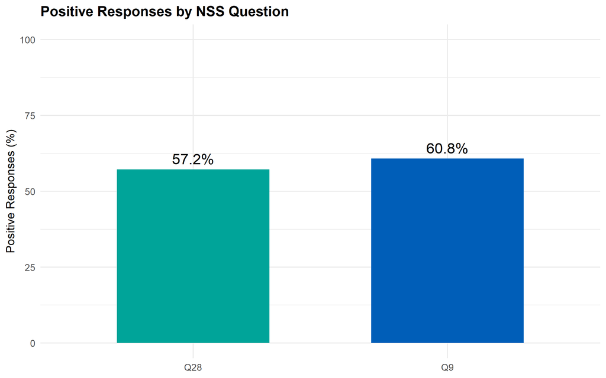

## Q9 and Q28 Difference Heatmap

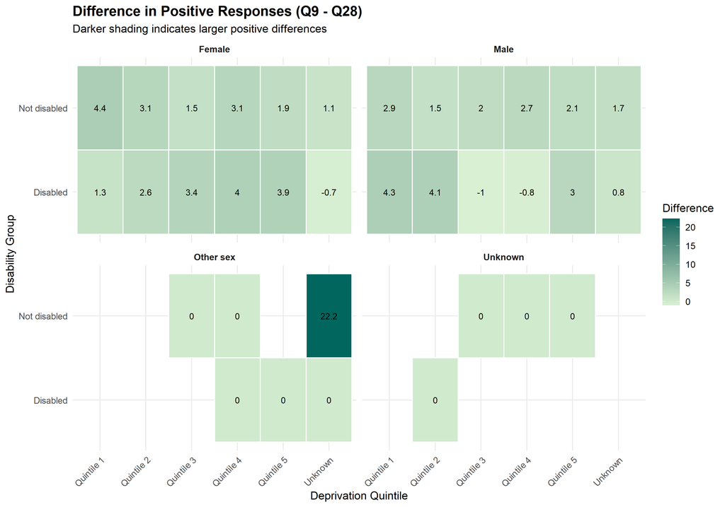

## Q9 Small Multiples

[figure not shown]

## Q28 Small Multiples

[figure not shown]

## NSS Question 9

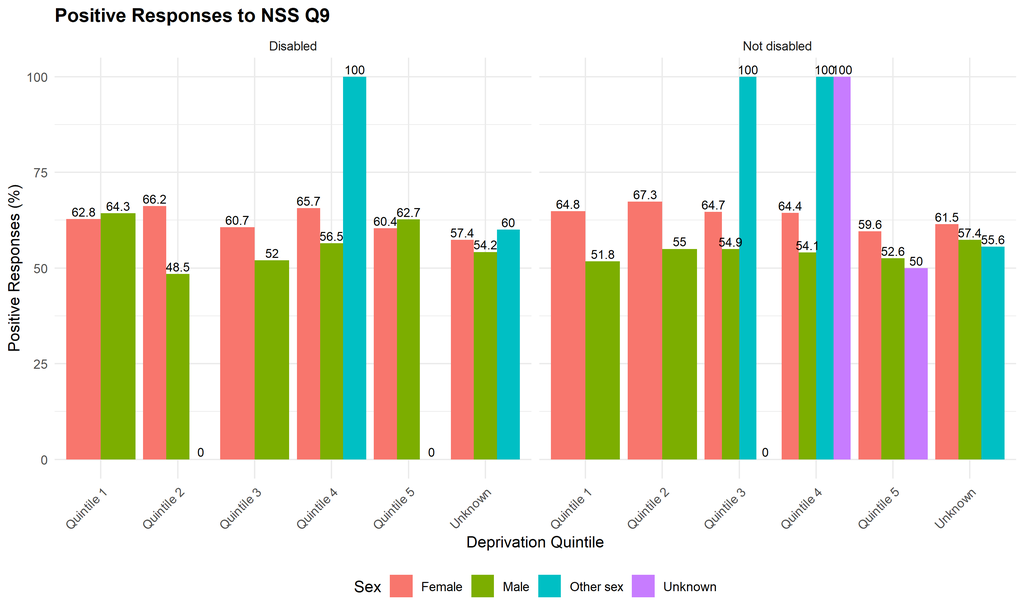

## NSS Question 28

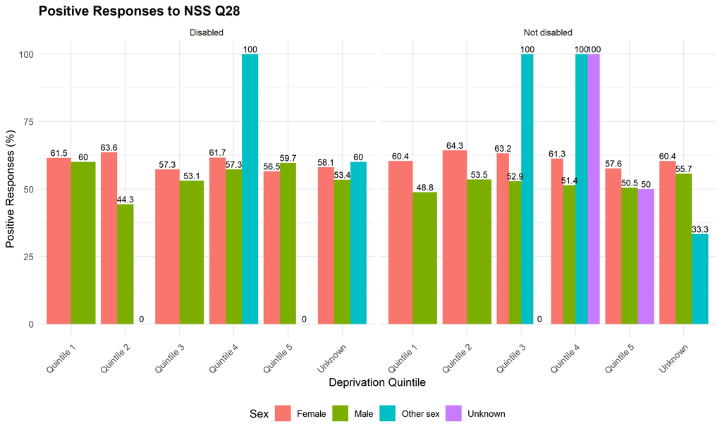

## 6. Maps (h2)

This section includes a static map and an interactive map. If you create a map in another package and import as an image, ensure it meets accessibility requirements for an infographic.

### Static map

This section includes a map generated in R.

#### Accessible maps

- Make sure different colours are easy to tell apart.
- More colours can make the map harder to read.
- Make sure the contrast between text labels and the background colour is at least 4.5:1.
- Try to make sure colours next to each other have a colour contrast of at least 3:1.
- If shape colours do not have enough contrast, use borders that do.
- Check colours using tools such as the [WebAIM contrast checker](https://webaim.org/resources/contrastchecker/)
- Do not rely on colour alone to communicate information (e.g. legends).
- Use clear and descriptive labels. Do not rely on hover interactions alone to communicate important information.

#### Features of this static map

- Labels are shown on the map.
- Alt text has been added for screen reader users.
- The shapefile has been made smaller so it loads more quickly.
- Only three colours are used.
- There is no map background so the shapes are more distinct.
- Data is available to download for users who cannot see the map.

Add a short description before or after the map to explain what it shows.

#### Map 1: Proportion of people aged under 25 in Northern Ireland by LGD

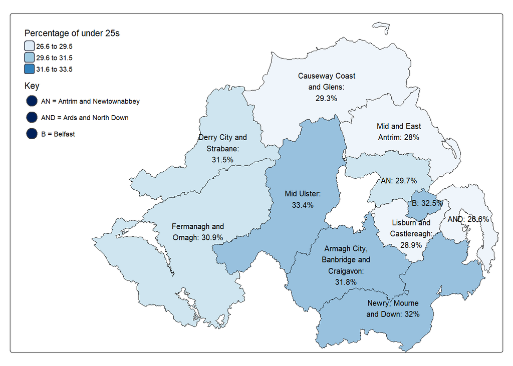

```r
df_map_data$xmod <- c(
  0.8,
  0,
  0,
  0.5,
  0,
  1.1,
  0.5,
  0.5,
  0,
  1,
  -1
)

df_map_data$ymod <- c(
  -0.5,
  0,
  0.2,
  0.3,
  0,
  0,
  1.4,
  -0.55,
  0.3,
  0,
  -1
)

# Plotting map:
tmap_mode("plot") # Set to "view" for interactive map or "plot" for static

map1_static_map <- tm_shape(
  df_map_data,
  # Default is km
  unit = "imperial"
) +
  tm_polygons(
    # Colours the map sections based on these values
    col = "lgd_young_perc",
    # Legend title
    title = "Percentage of under 25s",
    # Number of different colours to use
    n = 3,
    # Quantiles gives even sized groupings
    style = "quantile",
    # Colour palette. Execute the command tmaptools::palette_explorer() in R
    # console to see range of options
    palette = "Blues",
    # Add transparency to polygons improving contrast with text
    alpha = 0.5,
    legend.show = FALSE,
    border.col = "black"
  ) +
  tm_text(
    # add labels to polygons, change text colour to black and move
    # labels to fit within shapes
    "map_label",
    size = 0.8,
    col = "#000000",
    auto.placement = FALSE,
    xmod = "xmod",
    ymod = "ymod"
  ) +
  tm_add_legend(
    type = "polygons",
    fill = RColorBrewer::brewer.pal(
      3,
      "Blues"
    ),
    col = "#454A58",
    labels = c(
      "26.6 to 29.5",
      "29.6 to 31.5",
      "31.6 to 33.5"
    ),
    title = "Percentage of under 25s"
  ) +
  tm_add_legend(
    # add manual legend as a key
    "symbol",
    fill = "#00205b",
    title = "Key",
    labels = c(
      "AN = Antrim and Newtownabbey",
      "AND = Ards and North Down",
      "B = Belfast"
    )
  ) +
  tm_format(
    # setting format to worldwide creates a wider rectangle shape that
    # fits width of page
    "World_wide"
  ) +
  tm_layout(
    legend.position = c(
      "left",
      "top"
    )
  )

map1_static_map
```

```r
tmap_save(
  tm = map1_static_map,
  filename = here(
    "code",
    "demo",
    "demo_outputs",
    "figdata",
    "map1_static.png"
  ),
  width = 8,
  height = 6,
  units = "in"
)

map_download_data <- df_map_data |>
  sf::st_drop_geometry() |>
  select(
    lgd2014name,
    lgd_young_perc
  )

f_make_tables(
  data = map_download_data,
  title = "Map 1",
  data_style = ns_comma,
  data_dir = here(
    "code",
    "demo",
    "demo_outputs",
    "figdata"
  ),
  ggplot = TRUE
)
```

**Download**

Map 1.CSV (1kB)

Map 1.XLSX (7kB)

Map 1 as image

### Interactive maps

This section shows the same map produced as an interactive plot.

#### Features of interactive map

- The values are displayed on the map so that the user is not relying on a legend.
- The background map is greyscale and the detail is limited to help the shapes stand out.
- Council names and figures display on click.
- There was insufficient space to show council names on the map.
- The shapefile has been simplified to reduce file size and not slow page load speed.
- Data is available to download for users who cannot see the map.
- The default rendering of the map tabbed through each LGD shape, but without any highlighting or visible indication of this so it failed accessibility testing.
- Code has been added to remove the map shapes from the tab order to address this accessibility failure (see end of demo_report.Rmd)

Include descriptive text before or after the map.

#### Map 2: Interactive LGD map with additional information

The map shows the percentage of people aged under 25 in each Northern Ireland Local Government District. Values are also displayed directly on the map and are available in downloadable CSV and Excel formats below.

```r
df_map_data$xmod <- c(
  0,
  -1.5,
  0,
  -1.1,
  0,
  0,
  0,
  -1,
  0,
  0,
  -1
)

df_map_data$ymod <- c(
  0,
  1,
  0,
  0,
  0,
  0,
  1,
  0,
  0,
  0,
  -1
)

tmap_mode(
  # Set to "view" for interactive map or "plot" for static
  "view"
)

map2_interactive_map <- tm_shape(
  df_map_data |>
    select(
      lgd2014name,
      lgd_young_perc,
      map_label_value_only,
      ymod,
      xmod
    ),
  name = "Show data",
  # Default is km
  unit = "imperial"
) +
  tm_basemap(
    # Adds background map.
    "Esri.WorldGrayCanvas"
  ) +
  tm_polygons(
    # Colours the map sections based on these values
    col = "lgd_young_perc",
    # Number of different colours to use
    n = 3,
    # Quantiles gives even sized groupings
    style = "quantile",
    # Colour palette
    palette = "Blues",
    # Add transparency to polygons improving contrast with text
    alpha = 0.5,
    border.alpha = 1,
    legend.show = FALSE,
    popup.vars = c(
      "Council" = "lgd2014name",
      "Percentage under 25" = "lgd_young_perc"
    )
  ) +
  tm_add_legend(
    type = "polygons",
    fill = RColorBrewer::brewer.pal(
      3,
      "Blues"
    ),
    col = "#454A58",
    lwd = 1,
    labels = c(
      "26.6 to 29.5",
      "29.6 to 31.5",
      "31.6 to 33.5"
    ),
    title = "Percentage of under 25s"
  ) +
  tm_view(
    # Re-positioning legend
    view.legend.position = c(
      "left",
      "top"
    ),
    # Re-positioning layer controls
    control.position = c(
      "left",
      "bottom"
    ),
    leaflet.options = c(
      zoomControl = FALSE,
      # Removes zoom and drag options
      dragging = FALSE,
      keyboard = FALSE,
      boxZoom = FALSE,
      doubleClickZoom = FALSE,
      scrollWheelZoom = FALSE,
      tap = FALSE,
      touchZoom = FALSE,
      zoom = 8,
      minZoom = 8,
      maxZoom = 8,
      attributionControl = FALSE
    )
  ) +
  tm_text(
    # Label polygons, increase font size, set colour to black (better
    # contrast) and adjust positioning so they are contained as much as
    # possible within the polygons
    "map_label_value_only",
    size = 1.2,
    col = "#000000",
    auto.placement = FALSE,
    xmod = "xmod",
    ymod = "ymod"
  ) +
  tm_scalebar(
    width = 250
  )

map2_interactive_map
```

[interactive chart not shown]

```r
map_download_data <- df_map_data |>
  sf::st_drop_geometry() |>
  select(
    lgd2014name,
    lgd_young_perc
  )

f_make_tables(
  data = map_download_data,
  title = "Map 2 Data",
  data_style = ns_comma,
  data_dir = here(
    "code",
    "demo",
    "demo_outputs",
    "figdata"
  )
)
```

**Download**

Map 2 Data.CSV (1kB)

Map 2 Data.XLSX (7kB)

```r
# please also refer to the "alt text for maps" chunk in the source code of this
# section for additional configurations
```

#### Interactive point map with zoom and hover text

Map 3 shows an interactive map with points marked on it instead of areas. The map uses data about Jobs and Benefits Offices (JBOs) and the number of job vacancies at each office.

#### Features

- Users can hover over or select a point to see the office name and the number of vacancies.
- Users can zoom in and out and reset the view.
- The points can be made larger or smaller based on the data, or grouped together when many points are close to each other.
- The data is available to download or view as a table on the next tab.

The interactive map is not fully accessible to keyboard users. The underlying data are provided in the adjacent data tab and as downloadable files, although these alternatives do not communicate the spatial relationships shown by the map.

#### Map 3: Vacancies at Jobs and Benefits Offices

###### Map (interactive) output

```r
#### interactive map ####

map3_interactive_map <- leaflet(
  options = leafletOptions(
    minZoom = 8,
    maxZoom = 12
  )
) |>
  setView(
    lng = -6.5,
    lat = 54.6,
    zoom = 8.15
  ) |>
  addProviderTiles(
    "Esri.WorldGrayCanvas"
  )

map3_interactive_map <- addCircleMarkers(
  map = map3_interactive_map,
  data = df_jbo,
  lng = ~Longitude,
  lat = ~Latitude,
  color = "blue",
  radius = 10,
  label = lapply(
    paste0(
      df_jbo$JBO,
      ": ",
      df_jbo$Vacancies,
      " vacancies"
    ),
    HTML
  ),
  labelOptions = labelOptions(
    style = list(
      "font-size" = "14px"
    )
  )
) |>
  addEasyButton(
    easyButton(
      icon = "fa-globe",
      title = "Reset Zoom",
      onClick = JS("function(btn, map) { map.setView([54.6, -6.5], 8.15); }")
    )
  )

map3_interactive_map
```

[interactive chart not shown]

**Download**

Map 3 Data.CSV (1kB)

Map 3 Data.XLSX (8kB)

###### Map (interactive) data

```r
kable(
  map3_download_data,
  col.names = c(
    "Jobs and Benefits Office",
    "Vacancies"
  )
)
```

| Jobs and Benefits Office | Vacancies |
| --- | --- |
| Shaftesbury Square | 6,431 |
| Holywood Road | 4,411 |
| Antrim | 4,325 |
| Foyle/Lisnagelvin | 4,174 |
| Belfast North | 3,664 |
| Lisburn | 3,410 |
| Bangor | 2,921 |
| Portadown | 2,912 |
| Ballymena | 2,736 |
| Knockbreda | 2,258 |
| Newry | 2,041 |
| Newtownards | 1,992 |
| Coleraine | 1,872 |
| Magherafelt | 1,619 |
| Armagh | 1,612 |
| Enniskillen | 1,567 |
| Omagh | 1,255 |
| Dungannon | 1,198 |
| Lurgan | 1,098 |
| Banbridge | 863 |
| Falls Road | 850 |
| Newtownabbey | 834 |
| Cookstown | 804 |
| Downpatrick | 759 |
| Ballymoney | 754 |
| Limavady | 739 |
| Carrickfergus | 701 |
| Strabane | 670 |
| Andersonstown | 573 |
| Ballynahinch | 569 |
| Larne | 538 |
| Newcastle | 462 |
| Kilkeel | 426 |
| Shankill | 410 |

## 7. Download data

### Download buttons linked to charts and maps

The make_tables.R script in the functions folder contains the f_make_tables() each figure and map in Sections 5 and 6. The drop-down provides options to download the data as an Excel or CSV file, or to download an image of the chart or map as a PNG file.

The Excel and CSV files are created and saved to the figdata folder when the report is generated. When a user selects the PNG download option, the image is generated and saved to the user’s Downloads folder.

The f_make_tables function can be added after each figure or map. The main inputs used in this example are:

- data - the data used in the chart or map.
- title - the title used to create the downloaded filenames.
- data_style - the style applied to the data in the Excel file. Available styles can be found in the Style.R script.
- data_dir - the folder where the Excel and CSV files are saved. In this example, the file path is set in the demo configuration file.
- plotly_id - the ID used to identify the Plotly chart or map when generating the PNG image.

An example of how f_make_tables is used for Figure 1 is shown below. Select **Show code** to view the example.

```r
# call make tables function to create chart download buttons
f_make_tables(
  data = df_fig1_xls,
  title = fig1_title,
  data_style = ns_comma,
  data_dir = here(
    "code",
    "demo",
    "demo_outputs",
    "figdata"
  ),
  plotly_id = "fig1_chart"
)
```

**Download**

Figure 1.CSV (1kB)

Figure 1.XLSX (7kB)

Figure 1 as image

### Embed spreadsheet into report

Another way to provide downloadable data in an HTML report is to add a “Download data” link that links to an embedded spreadsheet.

To use this option, first run the demo_excel_tables.R script to create the spreadsheet in the demo output folder. You can also add an existing spreadsheet to the folder.

The embed_file function is then used to create the download button. You can set:

- the file path
- the file name
- the text shown on the button

Links to downloads should have file type and size in the link text [2022 Mid-year population estimates statistical bulletin pdf 545KB](https://www.nisra.gov.uk/system/files/statistics/Statistical%20Bulletin%20-%202022%20Mid-year%20Population%20Estimates%20for%20Northern%20Ireland.pdf).

Select Show Code below to see an example.

This option should only be used when needed. Embedded spreadsheets can make the HTML file much larger. Large files can take longer to process, create and load. They can also make it harder to collect usage statistics for the downloaded files.

Where possible, store spreadsheets outside the HTML report and add a link to them instead. This keeps the report smaller, faster to load and allows download statistics to be collected.

```r
# embeds the spreadsheets
embexcel <- embed_file(
  here(
    "code",
    "demo",
    "demo_outputs",
    "RAP_demo_tables.xlsx"
  ),
  text = "Publication tables: 15KB"
)

div(
  div(
    class = "row",
    style = "display: flex;",
    div(
      class = "row-indent"
    ),
    div(
      class = "download",
      "Download data: ",
      style = "font-size: 12pt"
    ),
    div(
      class = "row-indent"
    ),
    div(
      class = "xl-button2",
      HTML(embexcel) # <-- wrap with HTML()
    ),
    div(
      class = "download",
      style = paste0(
        "padding-top: 7px; ",
        "padding-left: 5px; ",
        "padding-right: 5px;"
      )
    )
  )
)
```

Download data:

Publication tables: 15KB

## 8. Notes for readers

This part is separate from the main report so it is easier to find.

Most reports have a section like this. It might be called Notes for Readers, Background Notes, or Helpful Information.

This section should include:

- meanings of important words, or links that explain them
- information about how good the data is and anything people should be careful about
- a link to a report that explains the quality of the data
- any important things people should know about the data, including its limits
- links to similar statistics from England, Scotland, Wales and, if needed, the Republic of Ireland If there are no similar statistics, explain why.

This section may also include (if relevant):

- information about how the statistics were made
- information about where the data came from
- links to other related statistics
- information about how people use the statistics and how they should be used
- links to social media accounts [X (Twitter)](https://x.com/NISRA) and [Facebook](https://www.facebook.com/nisra.gov.uk)
- information about extra statistical services
- the date of the next publication
- links to [previous publications](https://www.nisra.gov.uk/publications/2021-mid-year-population-estimates-northern-ireland)

### Requests for PDF Versions

NISRA reports are usually published as web pages instead of PDF files.

If someone asks for a PDF, one can be made by printing the web page as a PDF. However, these PDFs are not easy for everyone to use, so the web page is the preferred version. If a user requests a PDF version, one can be created by printing the HTML page to PDF using the browser’s print function.

## 9. Text presentation

This section includes a quote, more subheading levels, unordered lists, ordered lists and links.

### Quote box

**Mid Year Estimates:**  
Every June, NISRA counts how many people live in Northern Ireland. It also shares information about different places and areas across the country. A style like this can be used to explain important words or to make something stand out.

### Areas of Northern Ireland

#### Local government districts

1. Antrim and Newtownabbey (no ampersand).
2. Ards and North Down.
3. Armagh City, Banbridge and Craigavon.
4. Belfast.
5. Causeway Coast and Glens.
6. Derry City and Strabane.
7. Fermanagh and Omagh.
8. Lisburn and Castlereagh.
9. Mid and East Antrim.
10. Mid Ulster.
11. Newry, Mourne and Down.

#### Health and social care trusts in Northern Ireland

1. Belfast HSC Trust.
2. South Eastern HSC Trust.
3. Western HSC Trust.
4. Southern HSC Trust.
5. Northern HSC Trust.
6. Northern Ireland Ambulance Service.

#### Geography levels in Northern Ireland

- NUTS III areas - large parts of Northern Ireland that are used to group places together and compare information.
- Super Output Areas - small local areas that help us understand what is happening in different neighbourhoods.
- Census Small Areas - very small areas made up of a few streets or homes. They help us to count people and learn about local communities.

#### Former areas and health trusts in Northern Ireland

- Parliamentary Constituencies (Assembly Areas).
- Health and Social Care Trusts.
- The former Education and Library Boards.
- The former Health and Social Services Boards.
- The former NUTS-III areas.
- The former 582 Electoral Wards.

### Using bullet points.

There are two ways to use bullet points.

#### After a heading

- Start each bullet with a capital letter.
- End each bullet with a full stop.
- Keep each bullet short.

In a list within a sentence:

- add a short lead-in line before the list
- start each bullet with a lowercase letter, unless it starts with a name
- do not use full stops at the end of the bullets

For more help, see the ONS punctuation guide.

### Accordions

Accordions are useful when you want to switch between hiding and showing a large amount of content.

Notes can be placed inside an accordion, like the example below. Accordions help keep pages tidy. Users can open them when they want to read more information.

```r
htmltools::HTML(
  "
  <div class='accordion'>
    <button class='accordion-toggle' aria-expanded='false'
            aria-controls='panel1' id='accordion1'>
      Local Government Districts
      <span class='accordion-arrow'>⌵</span>
    </button>
    <div class='accordion-panel' id='panel1' role='region'
         aria-labelledby='accordion1'>

      <ul>
        <li>Antrim and Newtownabbey (no ampersand).</li>
        <li>Ards and North Down.</li>
        <li>Armagh City, Banbridge and Craigavon.</li>
        <li>Belfast.</li>
        <li>Causeway Coast and Glens.</li>
        <li>Derry and Strabane.</li>
        <li>Fermanagh and Omagh.</li>
        <li>Lisburn and Castlereagh.</li>
        <li>Mid and East Antrim.</li>
        <li>Mid Ulster.</li>
        <li>Newry, Mourne and Down.</li>
      </ul>

    </div>
  </div>

  <script>
  document
    .getElementById('accordion1')
    .addEventListener('click', function() {
      const expanded =
        this.getAttribute('aria-expanded') === 'true';
      const panel =
        document.getElementById(this.getAttribute('aria-controls'));

      this.setAttribute('aria-expanded', !expanded);

      if (!expanded) {
        panel.style.maxHeight = panel.scrollHeight + 'px';
        panel.style.opacity = '1';
        panel.style.transform = 'translateY(0)';
      } else {
        panel.style.maxHeight = '0';
        panel.style.opacity = '0';
        panel.style.transform = 'translateY(-10px)';
      }
    });
  </script>
  "
)
```

- Antrim and Newtownabbey (no ampersand).
- Ards and North Down.
- Armagh City, Banbridge and Craigavon.
- Belfast.
- Causeway Coast and Glens.
- Derry and Strabane.
- Fermanagh and Omagh.
- Lisburn and Castlereagh.
- Mid and East Antrim.
- Mid Ulster.
- Newry, Mourne and Down.

### Hyperlinks

A hyperlink is a piece of text which allows people to navigate between different web pages. When adding a link, do not use the web address as the link text.

Use words that tell users where the link will take them. If the link is to a file, include the file type and size in the link text.

For data downloads, it is usually better to link to the publication page rather than the file itself.

If you link directly to a file:

- include the file type and size in the link text
- tell users if the file opens in a new window

The hyperlink colour in this demo report was changed because the default colour did not have enough contrast to meet accessibility standards.

#### Examples of adding links

For a link that opens in the same browser window, put the link name in square brackets. Then put the url in round brackets immediately after. For accessibility links should open in the same window.

[NISRA - 2022 Mid Year Population Estimates for Northern Ireland](https://www.nisra.gov.uk/publications/2022-mid-year-population-estimates-northern-ireland)

```markdown
[NISRA - 2022 Mid Year Population Estimates for Northern Ireland](https://www.nisra.gov.uk/publications/2022-mid-year-population-estimates-northern-ireland)
```

Where a link will open in a new window the “(opens in a new window)” text should be added to the end of the link name. In addition an icon to show the user it opens in a new window can be added with R markdown code such as `<span class="new-tab-icon"></span>)`. When target = “_blank” is set the link opens in a new window or tab.

[NISRA - 2022 Mid Year Population Estimates for Northern Ireland (opens in a new window)](https://www.nisra.gov.uk/publications/2022-mid-year-population-estimates-northern-ireland)

```markdown
[NISRA - 2022 Mid Year Population Estimates for Northern Ireland (opens in a new window) <span class="new-tab-icon"></span>](https://www.nisra.gov.uk/publications/2022-mid-year-population-estimates-northern-ireland){target="_blank"}
```

If links take you directly to a download or file, then the link text should have the file type and size included below.

[2022 Mid-year population estimates statistical bulletin pdf 545KB](https://www.nisra.gov.uk/system/files/statistics/Statistical%20Bulletin%20-%202022%20Mid-year%20Population%20Estimates%20for%20Northern%20Ireland.pdf)

```markdown
[2022 Mid-year population estimates statistical bulletin pdf 545KB](https://www.nisra.gov.uk/system/files/statistics/Statistical%20Bulletin%20-%202022%20Mid-year%20Population%20Estimates%20for%20Northern%20Ireland.pdf)
```

## 10. Useful accessibility links

Some features may not work or be accessible in older browsers.

The [NISRA Accessibility Statement](https://datavis.nisra.gov.uk/dissemination/accessibility-statement-visualisations.html) is now included as a link in the footer of the RAP Skeleton.

[New Analysis Function website](https://analysisfunction.civilservice.gov.uk) - General guidance.

[New Guidance Hub](https://analysisfunction.civilservice.gov.uk/policy-store/) - Guidance hub including some specific accessibility guides and references (see below).

[Government Analysis Function - Accessibility support for statistical and analytical publications](https://analysisfunction.civilservice.gov.uk/news/accessibility-support-for-statistical-and-analytical-publications/) - Provides information on all the help that is available from the Government Analysis Function, including details on their online tool (basecamp for statistics) that has a message board and other functions where you can ask questions about accessibility as well as information on the available drop in clinics.

[Government Analysis Function - Making analytical publications accessible](https://analysisfunction.civilservice.gov.uk/policy-store/making-analytical-publications-accessible/) - Guide on making analytical publications accessible.

[Government Analysis Function - Releasing statistics in spreadsheets](https://analysisfunction.civilservice.gov.uk/policy-store/releasing-statistics-in-spreadsheets/) - General guide including specific section on accessibility with links to Web Content Accessibility Guidelines (WCAG) 2.2.

[Government Analysis Function - Making spreadsheets accessible: a checklist of the basics](https://analysisfunction.civilservice.gov.uk/policy-store/making-spreadsheets-accessible-a-brief-checklist-of-the-basics/) - Specific guide on making accessible spreadsheets.

[Government Analysis Function - Data visualisation: tables](https://analysisfunction.civilservice.gov.uk/policy-store/data-visualisation-tables/) - Guidance on how to present tables.

[Government Analysis Function - Data visualisation: charts](https://analysisfunction.civilservice.gov.uk/policy-store/data-visualisation-charts/) - Guidance on how to create accessible charts.

[Government Analysis Function - Data visualisation: colours](https://analysisfunction.civilservice.gov.uk/policy-store/data-visualisation-colours-in-charts/) - Guidance on using colours in data visualisations.

[Government Analysis Function - Data visualisation: examples](https://analysisfunction.civilservice.gov.uk/policy-store/data-visualisation-chart-examples/) - Specific examples of using the data visualisation guidance with real-life charts and tables.

[Government Analysis Function - infographics](https://analysisfunction.civilservice.gov.uk/policy-store/infographics/) - guidance on infographics.

[Office for National Statistics (ONS) - Style.ONS - A guide to writing about statistics](https://style.ons.gov.uk) - General style guide for writing about statistics. ‘Web accessibility’ section under ‘Writing for the web’ offers specifics around accessibility.

[NISRA Dissemination Branch guidance on creating an accessible infographic](https://nicsonline.sharepoint.com/:w:/r/sites/TM-DOF-NISRATEAM/Shared%20Documents/Dissemination%20Team/Creating%20an%20Accessible%20Infographic.DOCX?d=wbfd3f8b30e7b4e7d872b2f25bc4538b3&csf=1&web=1&e=0020gi) - Guidance shared by NISRA Dissemination Branch on how to create an accessible infographic.

## 11. Accredited official statistics and official statistics

Outputs should include a chapter detailing regulatory information regarding the Statistic type of the report. Example text for each of **Accredited Official Statistics**, **Official Statistics** and **Official Statistics in Development** can be found on the NISRA Teams Code Of Practice page.

It is recommended to use these templates and update them with your respective information accordingly.

## 12. Contact Details

The function called f_contact can also be used to add contact details automatically. This helps make reports look the same and easier for people to use.

Email addresses should all be lowercase jo.bloggs@nisra.gov.uk and it is good practice to include a named individual (some exemptions apply).

**Published by:** Dissemination Branch, Northern Ireland Statistics and Research Agency

**Lead Statistician:** John Smith

**Telephone:** 028 XX XXXXXX

**Email:** contact@nisra.gov.uk

### Accessibility contact

Please contact Dissemination Branch for assistance with accessibility requirements or alternative formats. Contact details are:

**Email:** info@nisra.gov.uk

**Telephone:** +44 (0)300 200 7836

Dissemination Branch  
NISRA  
Colby House  
Stranmillis Court  
BELFAST  
BT9 5RR